# CedV fusion

Amandine Gamble

21 janvier 2021

# Setup

```r
# Rmarkdown options
knitr::opts_chunk$set(warning = F)
```

```r
# working directory
path = "D:/work/postdoc_UCLA/1_project_PREEMPT/5_models/6_CedV_Yao/CedV_fusion"

# export the corresponding R file
# knitr::purl("scripts/data_analysis.Rmd", output = paste0(path, "/scripts/data_analysis.R"), documentation = 2)

# source file
file = "data_clean/Yeo_CedV_fusion.csv"

# needed packages
packages = c("tidyr", "ggplot2", "patchwork", "cowplot", "lme4", "lmerTest", "car", "kableExtra", "ggpubr", "magick", "multcomp", "nlme", "lsmeans", "dplyr")

# install and load packages
suppressMessages(invisible(lapply(
  packages,
  function(x) {
    if (!require(x, character.only = TRUE)) {
      install.packages(x, dependencies = TRUE)
      library(x, character.only = TRUE)
    }
  }
)))

# custom ggtheme for figures
ggtheme = theme_bw() +
  theme(
    plot.title = element_text(size = 10, hjust = 0, face = "bold", margin=margin(0, 0, 0, 0)),
    plot.margin = margin(6, 6, 6, 6),
    panel.grid.minor = element_blank(),
    panel.grid.major = element_blank(),
    axis.title.y.right = element_text(angle = 90),
    axis.title = element_text(size = 8),
    axis.text = element_text(size = 8, color = "black"),
    axis.line = element_line(size = 0.25, color = "black"),
    axis.ticks = element_line(size = 0.25, color = "black"),
    strip.text = element_text(size = 8),
    strip.background = element_blank(),
    legend.margin = margin(0, 0, 0, 0),
    legend.title = element_text(size = 8),
    legend.text = element_text(size = 8),
    legend.key = element_rect(fill = NA, color = NA),
    legend.key.size = unit(0.4, "cm"),
    legend.background = element_rect(colour = "transparent", fill = ggplot2::alpha("white", 0))
 )

# kable options
options(knitr.kable.NA = "")

# set working directory
setwd(path)

# import data
data = read.table(file, sep = ";", header = T)
```

Data produced by Yao Yu Yeo, Aguilar Lab, Cornell University. Raw data will be made available upon manuscript publication.

```r
# DATA FORMATTING

# order factors
data$virus = factor(data$virus, levels = c("Vector",
                                           "NiV", "NiV_167", "NiV_170",
                                           "HeV", "HeV_167", "HeV_170",
                                           "CedV", "CedV_188", "CedV_190",
                                           "CedV_193",  "CedV_196", "CedV_199", "CedV_202",
                                           "NiVG_CedVF", "NiVG_CedVF_167", "CedVG_NiVF", "CedVG_NiVF_193"))
data$variable = factor(data$variable, levels = c("CSE_G", "CSE_F",
                                                 "fusion", "fusion_mean",
                                                 "Tetramer", "Dimer", "Monomer1", "Monomer2",
                                                 "binding",
                                                 "CoIP_GHA", "IP_FFLAG", "Lysate_GHA"))

# calculate mean fusion per well for experiments for which data are reported for 5 fields per well
# to uniformize across experiments
data = aggregate(value ~ variable + virus + replicate + conditions + experiment + tag, data = data, mean, na.action = na.pass)
data[data$variable == "fusion", "variable"] = "fusion_mean"

# distinguish biological from technical replicates
data$replicate_bio = substr(data$replicate, 5, 5)
data$replicate_tec = substr(data$replicate, 7, 7)
data[data$replicate_tec == "", "replicate_tec"] = NA
```

# 1. CedV / NiV comparison

## 1.1. Data exploration

### 1.1.1. CSE and fusion

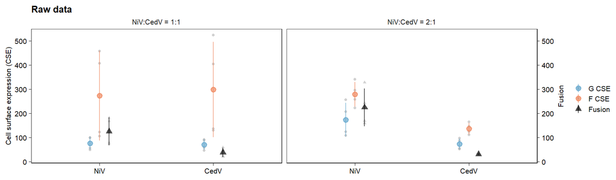

```r
# subset data of interest
CvN = subset(data, experiment == "fusogenicity NiV vs CedV",
             select = -c(experiment))

# calculate mean across technical replicates for figures
CSE_fusion_aggr = aggregate(value ~ variable + conditions + virus + replicate_bio, data = CvN, mean)

# plot raw data
ggplot(CSE_fusion_aggr, aes(x = virus, y = value, color = variable, shape = variable, group = variable)) +
  geom_point(size = 1, alpha = 0.7, position=position_dodge(width = 0.25), color = "grey") +
  stat_summary(fun.data = mean_sdl, fun.args = list(mult = 1), position=position_dodge(width = 0.25), alpha = 0.7) +
  facet_grid(. ~ conditions) +
  scale_y_continuous(name = "Cell surface expression (CSE)",
                     sec.axis = sec_axis(~ . * 1, name="Fusion")) +
  scale_shape_manual(values = c(19, 19, 17), labels = c("G CSE", "F CSE", "Fusion")) +
  scale_color_manual(values = c("#67a9cf", "#ef8a62", "black"), labels = c("G CSE", "F CSE", "Fusion")) +
  ggtheme + theme(axis.title.x = element_blank(), legend.title = element_blank()) +
  ggtitle("Raw data")
```

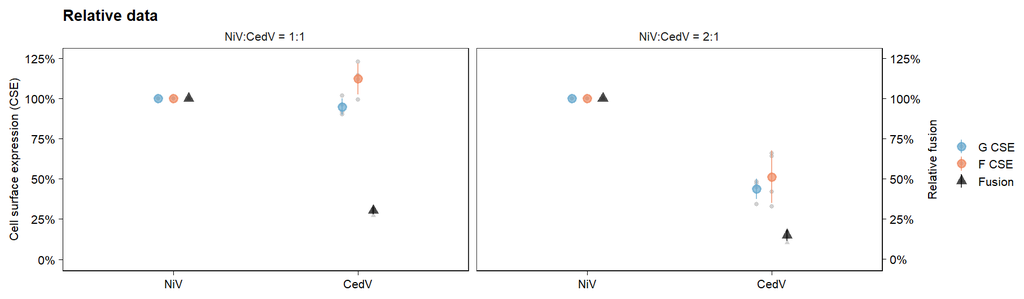

```r
# transform into relative data
CSE_fusion_aggr$value_relative = NA
for (i in 1:nrow(CSE_fusion_aggr)){
  CSE_fusion_aggr$value_relative[i] = CSE_fusion_aggr$value[i] /
    CSE_fusion_aggr[CSE_fusion_aggr$replicate_bio == CSE_fusion_aggr$replicate_bio[i] &
              CSE_fusion_aggr$conditions == CSE_fusion_aggr$conditions[i] &
              CSE_fusion_aggr$variable == CSE_fusion_aggr$variable[i] &
              CSE_fusion_aggr$virus == "NiV", "value"]
}
remove(i)

# plot relative data
ggplot(CSE_fusion_aggr, aes(x = virus, y = value_relative, color = variable, shape = variable, group = variable)) +
  geom_point(size = 1, alpha = 0.7, position=position_dodge(width = 0.25), color = "grey") +
  stat_summary(fun.data = mean_sdl, fun.args = list(mult = 1), position=position_dodge(width = 0.25), alpha = 0.7) +
  facet_grid(. ~ conditions) +
  scale_y_continuous(name = "Cell surface expression (CSE)", limits = c(-0.01,1.25), breaks = seq(0, 1.25, 0.25), labels = scales::percent,
                     sec.axis = sec_axis(~ . * 1, name="Relative fusion", breaks = seq(0, 1.25, 0.25), labels = scales::percent)) +
  scale_shape_manual(values = c(19, 19, 17), labels = c("G CSE", "F CSE", "Fusion")) +
  scale_color_manual(values = c("#67a9cf", "#ef8a62", "black"), labels = c("G CSE", "F CSE", "Fusion")) +
  ggtheme + theme(axis.title.x = element_blank(), legend.title = element_blank())+
  ggtitle("Relative data")
```

### 1.1.2. Fusion index

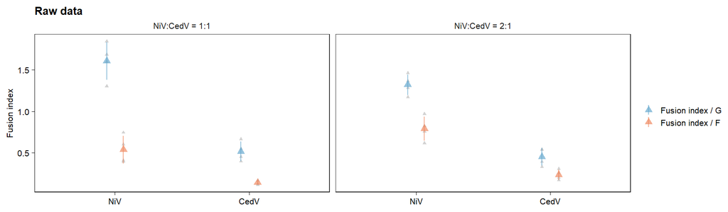

```r
# fusion index
FI = pivot_wider(names_from = variable, values_from = value, data = CvN)
FI$FI_G = FI$fusion_mean / FI$CSE_G
FI$FI_F = FI$fusion_mean / FI$CSE_F
FI = pivot_longer(cols = c(FI_G, FI_F), names_to = "variable", values_to = "value", data = FI)
FI$variable = factor(FI$variable, levels = c("FI_G", "FI_F"))

# calculate mean across technical replicates for figures
FI_aggr = aggregate(value ~ variable + conditions + virus + replicate_bio, data = FI, mean)

# plot raw data
ggplot(FI_aggr, aes(x = virus, y = value, color = variable, group = variable)) +
  geom_point(size = 1, alpha = 0.7, position=position_dodge(width = 0.25), color = "grey", shape = 17) +
  stat_summary(fun.data = mean_sdl, fun.args = list(mult = 1), position=position_dodge(width = 0.25), alpha = 0.7, shape = 17) +
  facet_grid(. ~ conditions) +
  scale_y_continuous(name = "Fusion index") +
  scale_color_manual(values = c("#67a9cf", "#ef8a62"), labels = c("Fusion index / G", "Fusion index / F")) +
  ggtheme + theme(axis.title.x = element_blank(), legend.title = element_blank()) +
  ggtitle("Raw data")
```

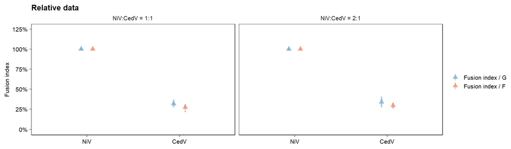

```r
# transform into relative data
FI_aggr$value_relative = NA
for (i in 1:nrow(FI_aggr)){
  FI_aggr$value_relative[i] = FI_aggr$value[i] /
    FI_aggr[FI_aggr$replicate_bio == FI_aggr$replicate_bio[i] &
              FI_aggr$conditions == FI_aggr$conditions[i] &
              FI_aggr$variable == FI_aggr$variable[i] &
              FI_aggr$virus == "NiV", "value"]
}
remove(i)

# plot relative data
ggplot(FI_aggr, aes(x = virus, y = value_relative, color = variable, group = variable)) +
  geom_point(size = 1, alpha = 0.7, position=position_dodge(width = 0.25), color = "grey", shape = 17) +
  stat_summary(fun.data = mean_sdl, fun.args = list(mult = 1), position=position_dodge(width = 0.25), alpha = 0.7, shape = 17) +
  facet_grid(. ~ conditions) +
  scale_y_continuous(name = "Fusion index", limits = c(-0.01,1.25), breaks = seq(0, 1.25, 0.25), labels = scales::percent) +
  scale_color_manual(values = c("#67a9cf", "#ef8a62"), labels = c("Fusion index / G", "Fusion index / F")) +
  ggtheme + theme(axis.title.x = element_blank(), legend.title = element_blank())+
  ggtitle("Relative data")
```

## 1.2. Publication figure

```r
plot_1 = ggplot(subset(CSE_fusion_aggr, conditions == "NiV:CedV = 1:1"), aes(x = virus, y = value_relative, color = variable, shape = variable, group = variable)) +
  geom_point(size = 1, alpha = 0.7, position=position_dodge(width = 0.25), color = "grey") +
  stat_summary(fun.data = mean_sdl, fun.args = list(mult = 1), position=position_dodge(width = 0.25), alpha = 0.7, size = 0.25) +
  scale_y_continuous(name = "Cell surface\nexpression (CSE)", limits = c(-0.01,1.25), breaks = seq(0, 1.25, 0.5), labels = scales::percent, sec.axis = sec_axis(~ . * 1, breaks = seq(0, 1.25, 0.5))) +
  scale_shape_manual(values = c(19, 19, 17), labels = c("G CSE", "F CSE", "Fusion")) +
  scale_color_manual(values = c("#67a9cf", "#ef8a62", "black"), labels = c("G CSE", "F CSE", "Fusion")) +
  ggtheme + theme(axis.title.x = element_blank(), legend.title = element_blank()) +
  theme(axis.text.x = element_blank(), axis.text.y.right = element_blank())

plot_2 = ggplot(subset(FI_aggr, conditions == "NiV:CedV = 1:1"), aes(x = virus, y = value_relative, color = variable, group = variable)) +
  geom_point(size = 1, alpha = 0.7, position=position_dodge(width = 0.25), color = "grey", shape = 17) +
  stat_summary(fun.data = mean_sdl, fun.args = list(mult = 1), position=position_dodge(width = 0.25), alpha = 0.7, shape = 17, size = 0.25) +
  scale_y_continuous(name = "Fusion\nindex (FI)", limits = c(-0.01,1.25), breaks = seq(0, 1.25, 0.5), labels = scales::percent) +
  scale_color_manual(values = c("#67a9cf", "#ef8a62"), labels = c("FI / G", "FI / F")) +
  ggtheme + theme(axis.title.x = element_blank(), legend.title = element_blank())

plot_3 = ggplot(subset(CSE_fusion_aggr, conditions == "NiV:CedV = 2:1"), aes(x = virus, y = value_relative, color = variable, shape = variable, group = variable)) +
  geom_point(size = 1, alpha = 0.7, position=position_dodge(width = 0.25), color = "grey") +
  stat_summary(fun.data = mean_sdl, fun.args = list(mult = 1), position=position_dodge(width = 0.25),  alpha = 0.7, size = 0.25) +
  scale_y_continuous(name = "Fusion", limits = c(-0.01,1.25), breaks = seq(0, 1.25, 0.5), labels = scales::percent, position = "right", sec.axis = sec_axis(~ . * 1, breaks = seq(0, 1.25, 0.5))) +
  scale_shape_manual(values = c(19, 19, 17), labels = c("G CSE", "F CSE", "Fusion")) +
  scale_color_manual(values = c("#67a9cf", "#ef8a62", "black"), labels = c("G CSE", "F CSE", "Fusion")) +
  ggtheme + theme(axis.title.x = element_blank(), legend.title = element_blank()) +
  theme(axis.text.x = element_blank(), axis.text.y.left = element_blank())

plot_4 = ggplot(subset(FI_aggr, conditions == "NiV:CedV = 2:1"), aes(x = virus, y = value_relative, color = variable, group = variable)) +
  geom_point(size = 1, alpha = 0.7, position=position_dodge(width = 0.25), color = "grey", shape = 17) +
  stat_summary(fun.data = mean_sdl, fun.args = list(mult = 1), position=position_dodge(width = 0.25),  alpha = 0.7, shape = 17, size = 0.25) +
  scale_y_continuous(name = "Fusion\nindex (FI)", limits = c(-0.01,1.25), breaks = seq(0, 1.25, 0.5), labels = scales::percent) +
  scale_color_manual(values = c("#67a9cf", "#ef8a62"), labels = c("FI / G", "FI / F")) +
  ggtheme + theme(axis.title.x = element_blank(), legend.title = element_blank()) +
  theme(axis.title.y = element_blank(), axis.text.y = element_blank())

# ASSEMBLE

# subassemblage
plot_left = (plot_1 + plot_2) + plot_layout(ncol = 1, heights = c(1, 1))
plot_right = (plot_3 + plot_4) + plot_layout(ncol = 1, heights = c(1, 1))

# complete assemblage
patchwork = (plot_left | plot_right) +
  plot_layout(guides = "collect") & theme(legend.position = "right", legend.box.just = "left") &
  theme(plot.tag = element_text(size = 8, face = "bold"))

# print figure
# patchwork

# save figure
ggsave(paste0("export/CedV_fusion_", "Fig2", ".pdf"),
       width = 15.5, height = 6, units = "cm", dpi = 600)
```

## 1.3. Statistical analyses

### 1.3.1. NiV:CeV = 1:1

Test 1: fusion; Test 2: fusion index / F; Test 3: fusion index / G

Homo: under the homoscedasticity assumption; Hetero: under the heteroscedasticity assumption

```r
# Tests

test_1_homo = lme(value ~ virus, random = ~ 1|replicate_bio,
                    data = subset(CvN, variable == "fusion_mean" & conditions == "NiV:CedV = 1:1"),
                    method = "ML")

test_1_hetero = lme(value ~ virus, random = ~ 1|replicate_bio,
                    data = subset(CvN, variable == "fusion_mean" & conditions == "NiV:CedV = 1:1"),
                    method = "ML",
                    weights = varIdent(form = ~ 1|virus))

anova(test_1_homo, test_1_hetero)
```

```
##               Model df      AIC      BIC    logLik   Test  L.Ratio p-value
## test_1_homo       1  4 159.4563 162.5467 -75.72817
## test_1_hetero     2  5 149.6083 153.4712 -69.80414 1 vs 2 11.84806   6e-04
```

```r
anova(test_1_hetero)
```

```
##             numDF denDF  F-value p-value
## (Intercept)     1    11 19.14848  0.0011
## virus           1    11 44.28832  <.0001
```

```r
test_2_homo = lme(value ~ virus, random = ~ 1|replicate_bio,
                    data = subset(FI, variable == "FI_F" & conditions == "NiV:CedV = 1:1"),
                    method = "ML")

test_2_hetero = lme(value ~ virus, random = ~ 1|replicate_bio,
                    data = subset(FI, variable == "FI_F" & conditions == "NiV:CedV = 1:1"),
                    method = "ML",
                    weights = varIdent(form = ~ 1|virus))

anova(test_2_homo, test_2_hetero)
```

```
##               Model df       AIC       BIC   logLik   Test  L.Ratio p-value
## test_2_homo       1  4 -23.09231 -20.00195 15.54616
## test_2_hetero     2  5 -35.98976 -32.12682 22.99488 1 vs 2 14.89745   1e-04
```

```r
anova(test_2_hetero)
```

```
##             numDF denDF   F-value p-value
## (Intercept)     1    11 113.03140  <.0001
## virus           1    11  65.30885  <.0001
```

```r
test_3_homo = lme(value ~ virus, random = ~ 1|replicate_bio,
                    data = subset(FI, variable == "FI_G" & conditions == "NiV:CedV = 1:1"),
                    method = "ML")

test_3_hetero = lme(value ~ virus, random = ~ 1|replicate_bio,
                    data = subset(FI, variable == "FI_G" & conditions == "NiV:CedV = 1:1"),
                    method = "ML",
                    weights = varIdent(form = ~ 1|virus))

anova(test_3_homo, test_3_hetero)
```

```
##               Model df       AIC       BIC    logLik   Test L.Ratio p-value
## test_3_homo       1  4 -10.19408 -7.103730  9.097042
## test_3_hetero     2  5 -12.62325 -8.760301 11.311622 1 vs 2 4.42916  0.0353
```

```r
anova(test_3_hetero)
```

```
##             numDF denDF  F-value p-value
## (Intercept)     1    11 118.1417  <.0001
## virus           1    11 340.5985  <.0001
```

```r
# Store and format results

stats = as.data.frame(rbind(
  summary(test_1_hetero)$tTable[2, ],
  summary(test_2_hetero)$tTable[2, ],
  summary(test_3_hetero)$tTable[2, ]))

stats$variable = c("Fusion",
                       "Fusion index / F",
                       "Fusion index / G")

stats$comparison = "CedV - NiV"

stats$test = "Wald test (t-ratio)"

stats = stats[, c("variable", "comparison", "test", "t-value", "p-value", "Value", "Std.Error")]
colnames(stats) = c("Variable", "Comparison", "Test", "Statistics", "p-value", "Estimate", "se")

stats = stats[order(stats$Variable), ]

stats = stats %>% mutate_if(is.numeric, round, digits = 3)

stats[stats$p_value < 0.001, "p-value"] = "< 0.001"

stats$Estimate = paste0(stats$Estimate, " ± ", stats$se)

stats = stats[, c("Variable", "Comparison", "Test", "Statistics", "p-value", "Estimate")]

kable(stats, digits = 3, row.names = F, caption =
        "Comparison of fusion performances between NiV and CedV with a 1:1 CSE ratio. The effect of virus genotype on the variable of interest was quantified with a Wald test (reporting a t-value) obtained from a mixed model allowing for heterogeneous variance among groups (here viruses) and including a random effect representing the experimental session. Fusion as number of nuclei included in syncytia, and fusion indices as number of nuclei included in syncytia / flow-cytometry signal."
      ) %>%
  kable_styling(bootstrap_options = c("striped", "hover", "condensed"))
```

Comparison of fusion performances between NiV and CedV with a 1:1 CSE ratio. The effect of virus genotype on the variable of interest was quantified with a Wald test (reporting a t-value) obtained from a mixed model allowing for heterogeneous variance among groups (here viruses) and including a random effect representing the experimental session. Fusion as number of nuclei included in syncytia, and fusion indices as number of nuclei included in syncytia / flow-cytometry signal.

| Variable | Comparison | Test | Statistics | p-value | Estimate |
| --- | --- | --- | --- | --- | --- |
| Fusion | CedV - NiV | Wald test (t-ratio) | -6.655 | 0 | -87.212 ± 13.105 |
| Fusion index / F | CedV - NiV | Wald test (t-ratio) | -8.081 | 0 | -0.397 ± 0.049 |
| Fusion index / G | CedV - NiV | Wald test (t-ratio) | -18.455 | 0 | -1.091 ± 0.059 |

### 1.3.2. NiV:CeV = 2:1

Test 1: fusion; Test 2: fusion index / F; Test 3: fusion index / G

Homo: under the homoscedasticity assumption; Hetero: under the heteroscedasticity assumption

```r
# Tests

test_1_homo = lme(value ~ virus, random = ~ 1|replicate_bio,
                    data = subset(CvN, variable == "fusion_mean" & conditions == "NiV:CedV = 2:1"),
                    method = "ML")

test_1_hetero = lme(value ~ virus, random = ~ 1|replicate_bio,
                    data = subset(CvN, variable == "fusion_mean" & conditions == "NiV:CedV = 2:1"),
                    method = "ML",
                    weights = varIdent(form = ~ 1|virus))

anova(test_1_homo, test_1_hetero)
```

```
##               Model df      AIC      BIC    logLik   Test  L.Ratio p-value
## test_1_homo       1  4 175.9149 179.0053 -83.95747
## test_1_hetero     2  5 138.2598 142.1227 -64.12990 1 vs 2 39.65514  <.0001
```

```r
anova(test_1_hetero)
```

```
##             numDF denDF  F-value p-value
## (Intercept)     1    11 581.6370  <.0001
## virus           1    11  56.3393  <.0001
```

```r
test_2_homo = lme(value ~ virus, random = ~ 1|replicate_bio,
                    data = subset(FI, variable == "FI_F" & conditions == "NiV:CedV = 2:1"),
                    method = "ML")

test_2_hetero = lme(value ~ virus, random = ~ 1|replicate_bio,
                    data = subset(FI, variable == "FI_F" & conditions == "NiV:CedV = 2:1"),
                    method = "ML",
                    weights = varIdent(form = ~ 1|virus))

anova(test_2_homo, test_2_hetero)
```

```
##               Model df       AIC       BIC   logLik   Test L.Ratio p-value
## test_2_homo       1  4 -21.85456 -18.76421 14.92728
## test_2_hetero     2  5 -32.38816 -28.52521 21.19408 1 vs 2 12.5336   4e-04
```

```r
anova(test_2_hetero)
```

```
##             numDF denDF   F-value p-value
## (Intercept)     1    11  74.20581  <.0001
## virus           1    11 176.30943  <.0001
```

```r
test_3_homo = lme(value ~ virus, random = ~ 1|replicate_bio,
                    data = subset(FI, variable == "FI_G" & conditions == "NiV:CedV = 2:1"),
                    method = "ML")

test_3_hetero = lme(value ~ virus, random = ~ 1|replicate_bio,
                    data = subset(FI, variable == "FI_G" & conditions == "NiV:CedV = 2:1"),
                    method = "ML",
                    weights = varIdent(form = ~ 1|virus))

anova(test_3_homo, test_3_hetero)
```

```
##               Model df       AIC       BIC   logLik   Test  L.Ratio p-value
## test_3_homo       1  4 -13.60861 -10.51825 10.80430
## test_3_hetero     2  5 -15.82879 -11.96584 12.91439 1 vs 2 4.220179  0.0399
```

```r
anova(test_3_hetero)
```

```
##             numDF denDF  F-value p-value
## (Intercept)     1    11 140.8293  <.0001
## virus           1    11 265.6006  <.0001
```

```r
# Store and format results

stats = as.data.frame(rbind(
  summary(test_1_hetero)$tTable[2, ],
  summary(test_2_hetero)$tTable[2, ],
  summary(test_3_hetero)$tTable[2, ]))

stats$variable = c("Fusion",
                       "Fusion index / F",
                       "Fusion index / G")

stats$comparison = "CedV - NiV"

stats$test = "Wald test (t-ratio)"

stats = stats[, c("variable", "comparison", "test", "t-value", "p-value", "Value", "Std.Error")]
colnames(stats) = c("Variable", "Comparison", "Test", "Statistics", "p-value", "Estimate", "se")

stats = stats[order(stats$Variable), ]

stats = stats %>% mutate_if(is.numeric, round, digits = 3)

stats[stats$p_value < 0.001, "p-value"] = "< 0.001"

stats$Estimate = paste0(stats$Estimate, " ± ", stats$se)

stats = stats[, c("Variable", "Comparison", "Test", "Statistics", "p-value", "Estimate")]

kable(stats, digits = 3, row.names = F, caption =
        "Comparison of fusion performances between NiV and CedV with a 2:1 CSE ratio. The effect of virus genotype on the variable of interest was quantified with a Wald test (reporting a t-value) obtained from a mixed model allowing for heterogeneous variance among groups (here viruses) and including a random effect representing the experimental session. Fusion as number of nuclei included in syncytia, and fusion indices as number of nuclei included in syncytia / flow-cytometry signal."
      ) %>%
  kable_styling(bootstrap_options = c("striped", "hover", "condensed"))
```

Comparison of fusion performances between NiV and CedV with a 2:1 CSE ratio. The effect of virus genotype on the variable of interest was quantified with a Wald test (reporting a t-value) obtained from a mixed model allowing for heterogeneous variance among groups (here viruses) and including a random effect representing the experimental session. Fusion as number of nuclei included in syncytia, and fusion indices as number of nuclei included in syncytia / flow-cytometry signal.

| Variable | Comparison | Test | Statistics | p-value | Estimate |
| --- | --- | --- | --- | --- | --- |
| Fusion | CedV - NiV | Wald test (t-ratio) | -7.506 | 0 | -193.45 ± 25.773 |
| Fusion index / F | CedV - NiV | Wald test (t-ratio) | -13.278 | 0 | -0.556 ± 0.042 |
| Fusion index / G | CedV - NiV | Wald test (t-ratio) | -16.297 | 0 | -0.87 ± 0.053 |

```r
# clean working space
remove(CvN, CSE_fusion_aggr, FI, FI_aggr)
remove(plot_1, plot_2, plot_3, plot_4, plot_left, plot_right, patchwork)
remove(test_1_hetero, test_1_homo, test_2_hetero, test_2_homo, test_3_hetero, test_3_homo, stats)
```

# 2. Headless mutant exploration

## 2.1. Data exploration

### 2.1.1. CedV mutant fusion

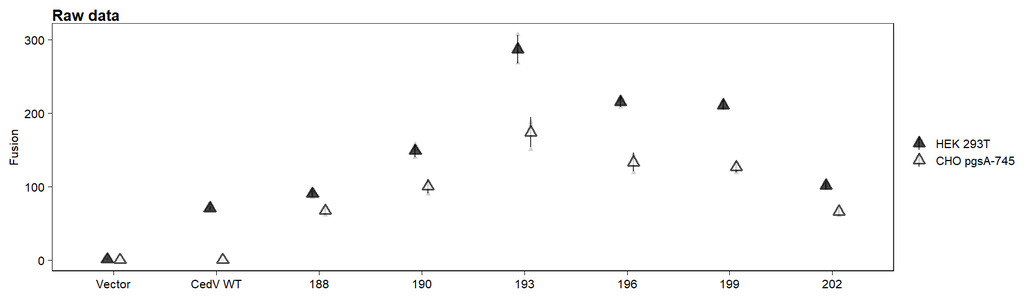

```r
# subset data of interest
Cm_fusion = subset(data, experiment == "fusion CedV mutants",
             select = -c(experiment))

# order factors
Cm_fusion$conditions = droplevels(Cm_fusion$conditions)
Cm_fusion$conditions = factor(Cm_fusion$conditions, levels = c("HEK 293T", "CHO pgsA-745"))

# plot raw data with color for replicates
# ggplot(Cm_fusion, aes(x = virus, y = value, color = replicate_bio, group = conditions)) +
#   geom_point(size = 1, alpha = 0.7, position=position_dodge(width = .25), shape = 17) +
#   scale_x_discrete(labels = c("Vector", "CedV WT", "188", "190", "193", "196", "199", "202")) +
#   scale_y_continuous(name = "Fusion") +
#   scale_fill_manual(values = c("black", "white")) +
#   ggtheme + theme(axis.title.x = element_blank(), legend.title = element_blank()) +
#   ggtitle("Raw data / replicate")

# plot raw data
ggplot(Cm_fusion, aes(x = virus, y = value, fill = conditions, group = conditions)) +
  geom_point(size = 1, alpha = 0.7, position=position_dodge(width = .25), color = "grey", shape = 17) +
  stat_summary(fun.data = mean_sdl, fun.args = list(mult = 1), position=position_dodge(width = .25), alpha = 0.7, shape = 24) +
  scale_x_discrete(labels = c("Vector", "CedV WT", "188", "190", "193", "196", "199", "202")) +
  scale_y_continuous(name = "Fusion") +
  scale_fill_manual(values = c("black", "white")) +
  ggtheme + theme(axis.title.x = element_blank(), legend.title = element_blank()) +
  ggtitle("Raw data")
```

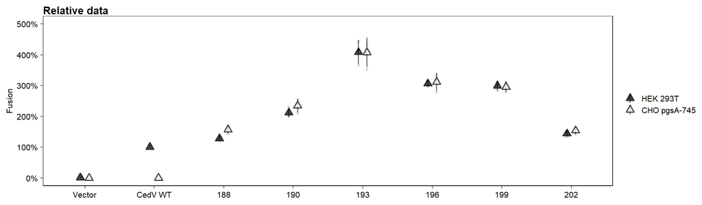

```r
# transform into relative data

# relative to wild-type CedV in HEK 293T

# Cm_fusion$value_relative = NA
# for (i in 1:nrow(Cm_fusion)){
#   Cm_fusion$value_relative[i] = Cm_fusion$value[i] /
#     Cm_fusion[Cm_fusion$replicate_bio == Cm_fusion$replicate_bio[i] &
#               Cm_fusion$conditions == "HEK 293T" &
#               Cm_fusion$variable == Cm_fusion$variable[i] &
#               Cm_fusion$virus == "CedV", "value"]
# }
# remove(i)

# with CedV 103 set at the same value in both cell types

Cm_fusion$value_relative = NA
for (i in 1:nrow(Cm_fusion)){
 Cm_fusion$value_relative[i] = Cm_fusion$value[i] /
   Cm_fusion[Cm_fusion$replicate_bio == Cm_fusion$replicate_bio[i] &
             Cm_fusion$conditions == Cm_fusion$conditions[i] &
             Cm_fusion$variable == Cm_fusion$variable[i] &
             Cm_fusion$virus == "CedV", "value"]
}
remove(i)

norm_factor = mean(Cm_fusion[Cm_fusion$virus == "CedV_193" & Cm_fusion$conditions == "CHO pgsA-745", "value"]) *
  mean(Cm_fusion[Cm_fusion$virus == "CedV" & Cm_fusion$conditions == "HEK 293T", "value"]) /
  mean(Cm_fusion[Cm_fusion$virus == "CedV_193" & Cm_fusion$conditions == "HEK 293T", "value"])
Cm_fusion[is.na(Cm_fusion$value_relative), "value_relative"] =
  Cm_fusion[is.na(Cm_fusion$value_relative), "value"] / norm_factor
Cm_fusion[Cm_fusion$value_relative == "Inf", "value_relative"] =
  Cm_fusion[Cm_fusion$value_relative == "Inf", "value"] / norm_factor
remove(norm_factor)

# plot relative data
ggplot(Cm_fusion, aes(x = virus, y = value_relative, fill = conditions, group = conditions)) +
  geom_point(size = 1, alpha = 0.7, position=position_dodge(width = .25), color = "grey", shape = 17) +
  stat_summary(fun.data = mean_sdl, fun.args = list(mult = 1), position=position_dodge(width = .25), alpha = 0.7, shape = 24) +
  scale_x_discrete(labels = c("Vector", "CedV WT", "188", "190", "193", "196", "199", "202")) +
  scale_y_continuous(name = "Fusion", limits = c(-0.01,5), breaks = seq(0, 5, 1), labels = scales::percent) +
  scale_fill_manual(values = c("black", "white")) +
  ggtheme + theme(axis.title.x = element_blank(), legend.title = element_blank()) +
  ggtitle("Relative data")
```

### 2.1.2. CedV mutant receptor binding

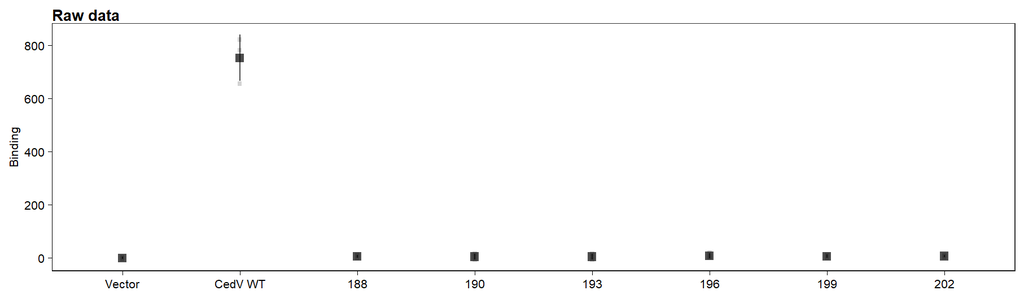

```r
Cm_binding = subset(data, experiment == "binding CedV mutants",
             select = -c(experiment))

# remove background noise
background = mean(Cm_binding[Cm_binding$virus == "Vector", "value"])
Cm_binding$value = Cm_binding$value - background
remove(background)

# plot raw data
ggplot(Cm_binding, aes(x = virus, y = value)) +
  geom_point(size = 1, alpha = 0.7, position=position_dodge(width = .25), color = "grey", shape = 15) +
  stat_summary(fun.data = mean_sdl, fun.args = list(mult = 1), alpha = 0.7, shape = 15) +
  scale_x_discrete(labels = c("Vector", "CedV WT", "188", "190", "193", "196", "199", "202")) +
  scale_y_continuous(name = "Binding") +
  ggtheme + theme(axis.title.x = element_blank(), legend.title = element_blank()) +
  ggtitle("Raw data")
```

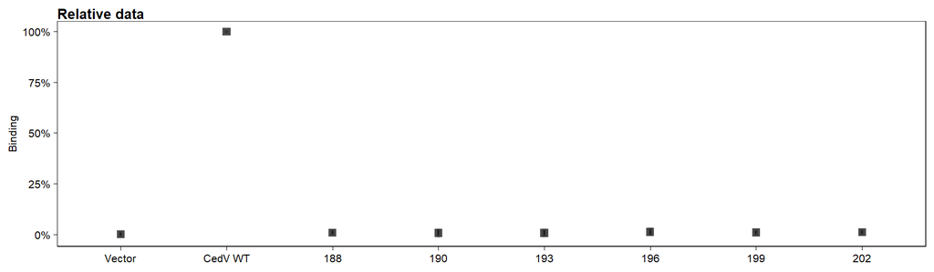

```r
# transform into relative data
Cm_binding$value_relative = NA
for (i in 1:nrow(Cm_binding)){
  Cm_binding$value_relative[i] = Cm_binding$value[i] /
    Cm_binding[Cm_binding$replicate_bio == Cm_binding$replicate_bio[i] &
              Cm_binding$conditions == Cm_binding$conditions[i] &
              Cm_binding$variable == Cm_binding$variable[i] &
              Cm_binding$virus == "CedV", "value"]
}
remove(i)

# plot relative data
ggplot(Cm_binding, aes(x = virus, y = value_relative)) +
  geom_point(size = 1, alpha = 0.7, position=position_dodge(width = .25), color = "grey", shape = 15) +
  stat_summary(fun.data = mean_sdl, fun.args = list(mult = 1), alpha = 0.7, shape = 15) +
  scale_x_discrete(labels = c("Vector", "CedV WT", "188", "190", "193", "196", "199", "202")) +
  scale_y_continuous(name = "Binding", limits = c(-0.01,1), breaks = seq(0, 1, 0.25), labels = scales::percent) +
  ggtheme + theme(axis.title.x = element_blank(), legend.title = element_blank()) +
  ggtitle("Relative data")
```

### 2.1.3. NiV mutant fusion

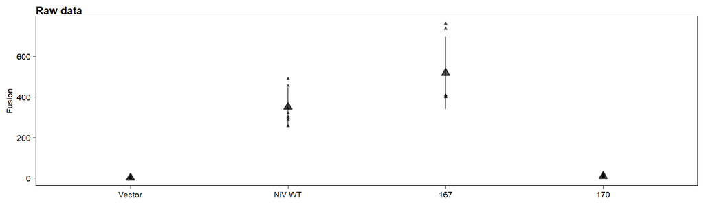

```r
# subset data of interest
Nm_fusion = subset(data, experiment == "fusion NiV mutants",
             select = -c(experiment))

# calculate mean across technical replicates for figures
Nm_fusion_aggr = aggregate(value ~ variable + virus + replicate_bio, data = Nm_fusion, mean)

# plot raw data
ggplot(Nm_fusion, aes(x = virus, y = value)) +
  geom_point(size = 1, alpha = 0.7, position=position_dodge(width = .25), solor = "grey", shape = 17) +
  stat_summary(fun.data = mean_sdl, fun.args = list(mult = 1), alpha = 0.7, shape = 24, fill = "black") +
  scale_x_discrete(labels = c("Vector", "NiV WT", "167", "170")) +
  scale_y_continuous(name = "Fusion") +
  ggtheme + theme(axis.title.x = element_blank(), legend.title = element_blank()) +
  ggtitle("Raw data")
```

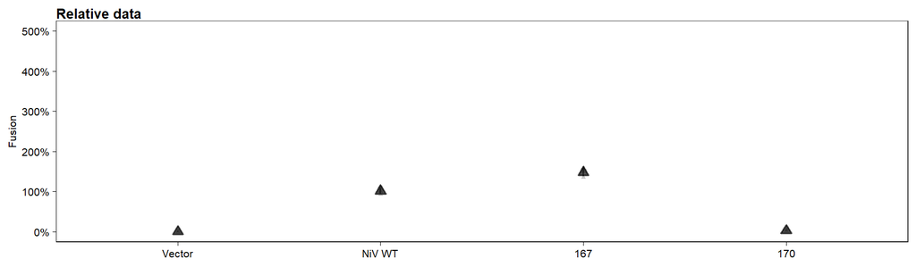

```r
# transform into relative data
Nm_fusion$value_relative = NA
for (i in 1:nrow(Nm_fusion)){
  Nm_fusion$value_relative[i] = Nm_fusion$value[i] /
    Nm_fusion[Nm_fusion$replicate_bio == Nm_fusion$replicate_bio[i] &
              Nm_fusion$conditions == Nm_fusion$conditions[i] &
              Nm_fusion$variable == Nm_fusion$variable[i] &
              Nm_fusion$virus == "NiV", "value"]
}
remove(i)

# plot relative data
ggplot(Nm_fusion, aes(x = virus, y = value_relative)) +
  geom_point(size = 1, alpha = 0.7, position=position_dodge(width = .25), color = "grey", shape = 17) +
  stat_summary(fun.data = mean_sdl, fun.args = list(mult = 1), alpha = 0.7, shape = 24, fill = "black") +
  scale_x_discrete(labels = c("Vector", "NiV WT", "167", "170")) +
  scale_y_continuous(name = "Fusion", limits = c(-0.01,5), breaks = seq(0, 5, 1), labels = scales::percent) +
  ggtheme + theme(axis.title.x = element_blank(), legend.title = element_blank()) +
  ggtitle("Relative data")
```

### 2.1.4. NiV mutant receptor binding

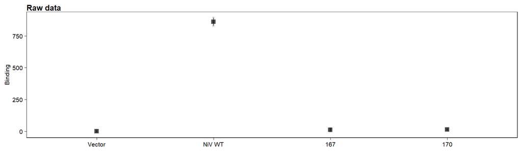

```r
Nm_binding = subset(data, experiment == "binding NiV mutants",
             select = -c(experiment))

# remove background noise
background = mean(Nm_binding[Nm_binding$virus == "Vector", "value"])
Nm_binding$value = Nm_binding$value - background
remove(background)

# plot raw data
ggplot(Nm_binding, aes(x = virus, y = value)) +
  geom_point(size = 1, alpha = 0.7, position=position_dodge(width = .25), color = "grey", shape = 15) +
  stat_summary(fun.data = mean_sdl, fun.args = list(mult = 1), alpha = 0.7, shape = 15) +
  scale_x_discrete(labels = c("Vector", "NiV WT", "167", "170")) +
  scale_y_continuous(name = "Binding") +
  ggtheme + theme(axis.title.x = element_blank(), legend.title = element_blank()) +
  ggtitle("Raw data")
```

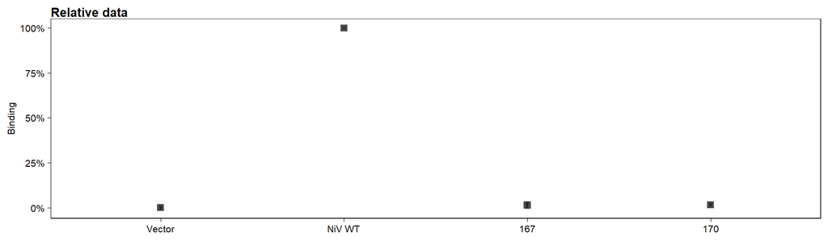

```r
# transform into relative data
Nm_binding$value_relative = NA
for (i in 1:nrow(Nm_binding)){
  Nm_binding$value_relative[i] = Nm_binding$value[i] /
    Nm_binding[Nm_binding$replicate_bio == Nm_binding$replicate_bio[i] &
              Nm_binding$conditions == Nm_binding$conditions[i] &
              Nm_binding$variable == Nm_binding$variable[i] &
              Nm_binding$virus == "NiV", "value"]
}
remove(i)

# plot relative data
ggplot(Nm_binding, aes(x = virus, y = value_relative)) +
  geom_point(size = 1, alpha = 0.7, position=position_dodge(width = .25), color = "grey", shape = 15) +
  stat_summary(fun.data = mean_sdl, fun.args = list(mult = 1), alpha = 0.7, shape = 15) +
  scale_x_discrete(labels = c("Vector", "NiV WT", "167", "170")) +
  scale_y_continuous(name = "Binding", limits = c(-0.01,1), breaks = seq(0, 1, 0.25), labels = scales::percent) +
  ggtheme + theme(axis.title.x = element_blank(), legend.title = element_blank()) +
  ggtitle("Relative data")
```

### 2.1.5. HeV mutant fusion

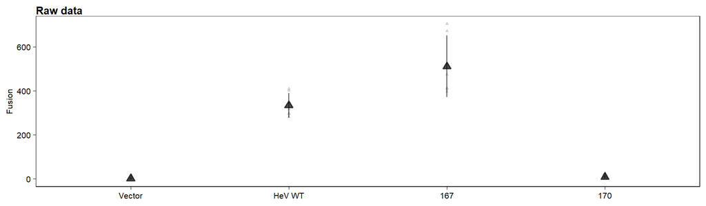

```r
# subset data of interest
Hm_fusion = subset(data, experiment == "fusion HeV mutants",
             select = -c(experiment))

# calculate mean across technical replicates for figures
Hm_fusion_aggr = aggregate(value ~ variable + virus + replicate_bio, data = Hm_fusion, mean)

# plot raw data
ggplot(Hm_fusion, aes(x = virus, y = value)) +
  geom_point(size = 1, alpha = 0.7, position=position_dodge(width = .25), color = "grey", shape = 17) +
  stat_summary(fun.data = mean_sdl, fun.args = list(mult = 1), alpha = 0.7, shape = 24, fill = "black") +
  scale_x_discrete(labels = c("Vector", "HeV WT", "167", "170")) +
  scale_y_continuous(name = "Fusion") +
  ggtheme + theme(axis.title.x = element_blank(), legend.title = element_blank()) +
  ggtitle("Raw data")
```

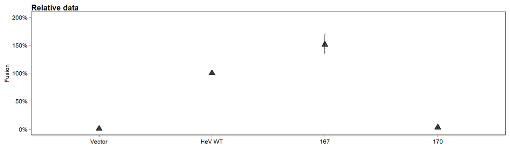

```r
# transform into relative data
Hm_fusion_aggr$value_relative = NA
for (i in 1:nrow(Hm_fusion_aggr)){
  Hm_fusion_aggr$value_relative[i] = Hm_fusion_aggr$value[i] /
    Hm_fusion_aggr[Hm_fusion_aggr$replicate_bio == Hm_fusion_aggr$replicate_bio[i] &
              Hm_fusion_aggr$variable == Hm_fusion_aggr$variable[i] &
              Hm_fusion_aggr$virus == "HeV", "value"]
}
remove(i)

# plot relative data
ggplot(Hm_fusion_aggr, aes(x = virus, y = value_relative)) +
  geom_point(size = 1, alpha = 0.7, position=position_dodge(width = .25), color = "grey", shape = 17) +
  stat_summary(fun.data = mean_sdl, fun.args = list(mult = 1), alpha = 0.7, shape = 24, fill = "black") +
  scale_x_discrete(labels = c("Vector", "HeV WT", "167", "170")) +
  scale_y_continuous(name = "Fusion", limits = c(-0.01,2), breaks = seq(0, 2, 0.5), labels = scales::percent) +
  ggtheme + theme(axis.title.x = element_blank(), legend.title = element_blank()) +
  ggtitle("Relative data")
```

### 2.1.6. HeV mutant receptor binding

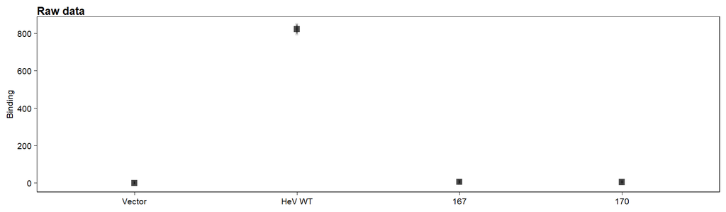

```r
Hm_binding = subset(data, experiment == "binding HeV mutants",
             select = -c(experiment))

# remove background noise
background = mean(Hm_binding[Hm_binding$virus == "Vector", "value"])
Hm_binding$value = Hm_binding$value - background
remove(background)

# plot raw data
ggplot(Hm_binding, aes(x = virus, y = value)) +
  geom_point(size = 1, alpha = 0.7, position=position_dodge(width = .25), color = "grey", shape = 15) +
  stat_summary(fun.data = mean_sdl, fun.args = list(mult = 1), alpha = 0.7, shape = 15) +
  scale_x_discrete(labels = c("Vector", "HeV WT", "167", "170")) +
  scale_y_continuous(name = "Binding") +
  ggtheme + theme(axis.title.x = element_blank(), legend.title = element_blank()) +
  ggtitle("Raw data")
```

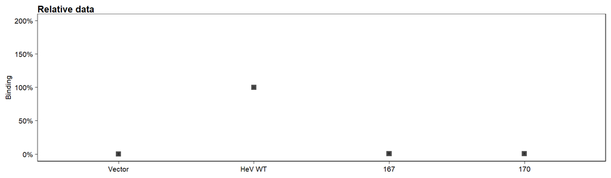

```r
# transform into relative data
Hm_binding$value_relative = NA
for (i in 1:nrow(Hm_binding)){
  Hm_binding$value_relative[i] = Hm_binding$value[i] /
    Hm_binding[Hm_binding$replicate_bio == Hm_binding$replicate_bio[i] &
              Hm_binding$conditions == Hm_binding$conditions[i] &
              Hm_binding$variable == Hm_binding$variable[i] &
              Hm_binding$virus == "HeV", "value"]
}
remove(i)

# plot relative data
ggplot(Hm_binding, aes(x = virus, y = value_relative)) +
  geom_point(size = 1, alpha = 0.7, position=position_dodge(width = .25), color = "grey", shape = 15) +
  stat_summary(fun.data = mean_sdl, fun.args = list(mult = 1), alpha = 0.7, shape = 15) +
  scale_x_discrete(labels = c("Vector", "HeV WT", "167", "170")) +
  scale_y_continuous(name = "Binding", limits = c(-0.01,2), breaks = seq(0, 2, 0.5), labels = scales::percent) +
  ggtheme + theme(axis.title.x = element_blank(), legend.title = element_blank()) +
  ggtitle("Relative data")
```

## 2.2. Publication figure

```r
plot_1 = ggplot(Cm_fusion, aes(x = virus, y = value_relative, fill = conditions, group = conditions)) +
  geom_point(size = 1, alpha = 0.7, position=position_dodge(width = .25), color = "grey", shape = 17) +
  stat_summary(fun.data = mean_sdl, fun.args = list(mult = 1), position=position_dodge(width = .25), alpha = 0.7, shape = 24, size = 0.25) +
  scale_x_discrete(labels = c("Vector", "CedV\nWT", "188", "190", "193", "196", "199", "202")) +
  scale_y_continuous(name = "Fusion", limits = c(-0.01,5), breaks = seq(0, 5, 1), labels = scales::percent) +
  scale_fill_manual(values = c("black", "white")) +
  ggtheme + theme(axis.title.x = element_blank(), legend.title = element_blank()) +
  theme(legend.position = c(0.99, 1.02), legend.justification = c(1, 1)) +
  theme(axis.text.x = element_blank()) +
  theme(legend.key.size = unit(0, 'lines'))

plot_2 = ggplot(Nm_fusion, aes(x = virus, y = value_relative)) +
  geom_point(size = 1, alpha = 0.7, position=position_dodge(width = .25), color = "grey", shape = 17) +
  stat_summary(fun.data = mean_sdl, fun.args = list(mult = 1), alpha = 0.7, shape = 24, fill = "black", size = 0.25) +
  scale_x_discrete(labels = c("Vector", "NiV\nWT", "167", "170")) +
  scale_y_continuous(name = "Fusion", limits = c(-0.01,5), breaks = seq(0, 5, 1), labels = scales::percent) +
  ggtheme + theme(axis.title.x = element_blank(), legend.title = element_blank()) +
  theme(axis.text.x = element_blank(), axis.title.y = element_blank(), axis.text.y = element_blank())

plot_3=ggplot(Hm_fusion_aggr, aes(x = virus, y = value_relative)) +
  geom_point(size = 1, alpha = 0.7, position=position_dodge(width = .25), color = "grey", shape = 17) +
  stat_summary(fun.data = mean_sdl, fun.args = list(mult = 1), alpha = 0.7, shape = 24, fill = "black", size = 0.25) +
  scale_x_discrete(labels = c("Vector", "HeV\nWT", "167", "170")) +
  scale_y_continuous(name = "Fusion", limits = c(-0.01,5), breaks = seq(0, 5, 1), labels = scales::percent) +
  ggtheme + theme(axis.title.x = element_blank(), legend.title = element_blank()) +
  theme(axis.text.x = element_blank(), axis.title.y = element_blank(), axis.text.y = element_blank())

plot_4 = ggplot(Cm_binding, aes(x = virus, y = value_relative)) +
  geom_point(size = 1, alpha = 0.7, position=position_dodge(width = .25), color = "grey", shape = 15) +
  stat_summary(fun.data = mean_sdl, fun.args = list(mult = 1), alpha = 0.7, shape = 15, size = 0.25) +
  scale_x_discrete(labels = c("Vector", "CedV\nWT", "188", "190", "193", "196", "199", "202")) +
  scale_y_continuous(name = "Binding", limits = c(-0.01,1.1), breaks = seq(0, 1, 0.5), labels = scales::percent) +
  ggtheme + theme(axis.title.x = element_blank(), legend.title = element_blank())

plot_5 = ggplot(Nm_binding, aes(x = virus, y = value_relative)) +
  geom_point(size = 1, alpha = 0.7, position=position_dodge(width = .25), color = "grey", shape = 15) +
  stat_summary(fun.data = mean_sdl, fun.args = list(mult = 1), alpha = 0.7, shape = 15, size = 0.25) +
  scale_x_discrete(labels = c("Vector", "NiV\nWT", "167", "170")) +
  scale_y_continuous(name = "Binding", limits = c(-0.01,1.1), breaks = seq(0, 1, 0.5), labels = scales::percent) +
  ggtheme + theme(axis.title.x = element_blank(), axis.title.y = element_blank(), axis.text.y = element_blank(), legend.title = element_blank())

plot_6 = ggplot(Hm_binding, aes(x = virus, y = value_relative)) +
  geom_point(size = 1, alpha = 0.7, position=position_dodge(width = .25), color = "grey", shape = 15) +
  stat_summary(fun.data = mean_sdl, fun.args = list(mult = 1), alpha = 0.7, shape = 15, size = 0.25) +
  scale_x_discrete(labels = c("Vector", "HeV\nWT", "167", "170")) +
  scale_y_continuous(name = "Binding", limits = c(-0.01,1.1), breaks = seq(0, 1, 0.5), labels = scales::percent) +
  ggtheme + theme(axis.title.x = element_blank(), axis.title.y = element_blank(), axis.text.y = element_blank(), legend.title = element_blank())

# ASSEMBLE

plot_top = (plot_1 | plot_2 | plot_3) + plot_layout(ncol = 3, widths = c(1,0.5, 0.5))
plot_lower = (plot_4 | plot_5 | plot_6) + plot_layout(ncol = 3, widths = c(1,0.5, 0.5))

# complete assemblage
patchwork = (plot_top / plot_lower)  +
  plot_layout(nrow = 2, heights = c(1,0.3)) & theme(plot.tag = element_text(size = 8, face = "bold"))

# print figure
# patchwork

# save figure
ggsave(paste0("export/CedV_fusion_", "Fig3", ".pdf"),
       width = 15.5, height = 8, units = "cm", dpi = 600)
```

## 2.3. Statistical analyses

### 2.3.1. CedV mutant fusion in HEK 293T

Homo: under the homoscedasticity assumption; Hetero: under the heteroscedasticity assumption

```r
# Tests

test_1_homo = lme(value ~ virus, random = ~ 1|replicate_bio,
                    data = subset(Cm_fusion, conditions == "HEK 293T"),
                    method = "ML")

test_1_hetero = lme(value ~ virus, random = ~ 1|replicate_bio,
                    data = subset(Cm_fusion, conditions == "HEK 293T"),
                    method = "ML",
                    weights = varIdent(form = ~ 1|virus))

anova(test_1_homo, test_1_hetero)
```

```
##               Model df      AIC      BIC    logLik   Test  L.Ratio p-value
## test_1_homo       1 10 180.7621 192.5426 -80.38104
## test_1_hetero     2 17 154.6457 174.6727 -60.32288 1 vs 2 40.11632  <.0001
```

```r
anova(test_1_hetero)
```

```
##             numDF denDF   F-value p-value
## (Intercept)     1    14  409.0212  <.0001
## virus           7    14 2017.8588  <.0001
```

```r
tukey_1 = lsmeans(test_1_hetero, pairwise ~ virus, adjust = "tukey")

# Store and format results

stats = as.data.frame(anova(test_1_hetero)[2, ])

stats$variable = c("Fusion")

stats$comparison = NA

stats$test = "Wald test (F-value)"

stats$Value = NA
stats$Std.Error = NA

stats = stats[, c("variable", "comparison", "test", "F-value", "p-value", "Value", "Std.Error")]
colnames(stats) = c("Variable", "Comparison", "Test", "Statistics", "p_value", "Estimate", "se")

tukey = as.data.frame(tukey_1[[2]])

tukey$variable = c("Fusion")

tukey$test = "Tukey pairwise Comparison (t-ratio)"

tukey = tukey[, c("variable", "contrast", "test", "t.ratio", "p.value", "estimate", "SE")]
colnames(tukey) = c("Variable", "Comparison", "Test", "Statistics", "p_value", "Estimate", "se")

stats = rbind(stats, tukey)

stats = stats[order(stats$Variable), ]

stats = stats %>% mutate_if(is.numeric, round, digits = 3)

stats[stats$p_value < 0.001, "p_value"] = "< 0.001"

stats$Estimate = paste0(stats$Estimate, " ± ", stats$se)

stats = stats[, c("Variable", "Comparison", "Test", "Statistics", "p_value", "Estimate")]
stats[stats$Estimate == ("NA ± NA"), "Estimate"] = NA

kable(stats, digits = 3, row.names = F,
      caption =
        "Comparison of fusion performances among CedV mutants in HEK 293T cells. The effect of virus genotype on the variable of interest was quantified with a Wald test (reporting an F-value) obtained from a mixed model allowing for heterogeneous variance among groups (here G genotype) and including a random effect representing the experimental session. As this experiment included more than two groups, post-hoc pairwise comparisons between genotypes were then performed using a Tukey test (reporting a t-ratio). Fusion was quantified as number of nuclei included in syncytia.."
      ) %>%
  kable_styling(bootstrap_options = c("striped", "hover", "condensed"))
```

Comparison of fusion performances among CedV mutants in HEK 293T cells. The effect of virus genotype on the variable of interest was quantified with a Wald test (reporting an F-value) obtained from a mixed model allowing for heterogeneous variance among groups (here G genotype) and including a random effect representing the experimental session. As this experiment included more than two groups, post-hoc pairwise comparisons between genotypes were then performed using a Tukey test (reporting a t-ratio). Fusion was quantified as number of nuclei included in syncytia..

| Variable | Comparison | Test | Statistics | p_value | Estimate |
| --- | --- | --- | --- | --- | --- |
| Fusion |  | Wald test (F-value) | 2017.859 | < 0.001 |  |
| Fusion | Vector - CedV | Tukey pairwise Comparison (t-ratio) | -46.830 | < 0.001 | -69.6 ± 1.486 |
| Fusion | Vector - CedV_188 | Tukey pairwise Comparison (t-ratio) | -35.749 | < 0.001 | -89.333 ± 2.499 |
| Fusion | Vector - CedV_190 | Tukey pairwise Comparison (t-ratio) | -28.711 | < 0.001 | -148.067 ± 5.157 |
| Fusion | Vector - CedV_193 | Tukey pairwise Comparison (t-ratio) | -25.643 | < 0.001 | -286.2 ± 11.161 |
| Fusion | Vector - CedV_196 | Tukey pairwise Comparison (t-ratio) | -57.011 | < 0.001 | -214.6 ± 3.764 |
| Fusion | Vector - CedV_199 | Tukey pairwise Comparison (t-ratio) | -62.282 | < 0.001 | -210 ± 3.372 |
| Fusion | Vector - CedV_202 | Tukey pairwise Comparison (t-ratio) | -45.657 | < 0.001 | -100.4 ± 2.199 |
| Fusion | CedV - CedV_188 | Tukey pairwise Comparison (t-ratio) | -6.791 | < 0.001 | -19.733 ± 2.906 |
| Fusion | CedV - CedV_190 | Tukey pairwise Comparison (t-ratio) | -14.623 | < 0.001 | -78.467 ± 5.366 |
| Fusion | CedV - CedV_193 | Tukey pairwise Comparison (t-ratio) | -19.238 | < 0.001 | -216.6 ± 11.259 |
| Fusion | CedV - CedV_196 | Tukey pairwise Comparison (t-ratio) | -35.839 | < 0.001 | -145 ± 4.046 |
| Fusion | CedV - CedV_199 | Tukey pairwise Comparison (t-ratio) | -38.115 | < 0.001 | -140.4 ± 3.684 |
| Fusion | CedV - CedV_202 | Tukey pairwise Comparison (t-ratio) | -11.612 | < 0.001 | -30.8 ± 2.652 |
| Fusion | CedV_188 - CedV_190 | Tukey pairwise Comparison (t-ratio) | -10.250 | < 0.001 | -58.733 ± 5.73 |
| Fusion | CedV_188 - CedV_193 | Tukey pairwise Comparison (t-ratio) | -17.213 | < 0.001 | -196.867 ± 11.437 |
| Fusion | CedV_188 - CedV_196 | Tukey pairwise Comparison (t-ratio) | -27.731 | < 0.001 | -125.267 ± 4.517 |
| Fusion | CedV_188 - CedV_199 | Tukey pairwise Comparison (t-ratio) | -28.759 | < 0.001 | -120.667 ± 4.196 |
| Fusion | CedV_188 - CedV_202 | Tukey pairwise Comparison (t-ratio) | -3.326 | 0.071 | -11.067 ± 3.327 |
| Fusion | CedV_190 - CedV_193 | Tukey pairwise Comparison (t-ratio) | -11.235 | < 0.001 | -138.133 ± 12.295 |
| Fusion | CedV_190 - CedV_196 | Tukey pairwise Comparison (t-ratio) | -10.422 | < 0.001 | -66.533 ± 6.384 |
| Fusion | CedV_190 - CedV_199 | Tukey pairwise Comparison (t-ratio) | -10.053 | < 0.001 | -61.933 ± 6.161 |
| Fusion | CedV_190 - CedV_202 | Tukey pairwise Comparison (t-ratio) | 8.503 | < 0.001 | 47.667 ± 5.606 |
| Fusion | CedV_193 - CedV_196 | Tukey pairwise Comparison (t-ratio) | 6.079 | 0.001 | 71.6 ± 11.778 |
| Fusion | CedV_193 - CedV_199 | Tukey pairwise Comparison (t-ratio) | 6.536 | < 0.001 | 76.2 ± 11.659 |
| Fusion | CedV_193 - CedV_202 | Tukey pairwise Comparison (t-ratio) | 16.334 | < 0.001 | 185.8 ± 11.375 |
| Fusion | CedV_196 - CedV_199 | Tukey pairwise Comparison (t-ratio) | 0.910 | 0.98 | 4.6 ± 5.053 |
| Fusion | CedV_196 - CedV_202 | Tukey pairwise Comparison (t-ratio) | 26.202 | < 0.001 | 114.2 ± 4.358 |
| Fusion | CedV_199 - CedV_202 | Tukey pairwise Comparison (t-ratio) | 27.234 | < 0.001 | 109.6 ± 4.024 |

### 2.3.2. CedV mutant fusion in CHO pgsA-745

Homo: under the homoscedasticity assumption; Hetero: under the heteroscedasticity assumption

```r
# Tests

test_1_homo = lme(value ~ virus, random = ~ 1|replicate_bio,
                    data = subset(Cm_fusion, conditions == "CHO pgsA-745"),
                    method = "ML")

test_1_hetero = lme(value ~ virus, random = ~ 1|replicate_bio,
                    data = subset(Cm_fusion, conditions == "CHO pgsA-745"),
                    method = "ML",
                    weights = varIdent(form = ~ 1|virus))

anova(test_1_homo, test_1_hetero)
```

```
##               Model df      AIC      BIC    logLik   Test  L.Ratio p-value
## test_1_homo       1 10 182.4651 194.2456 -81.23254
## test_1_hetero     2 17 172.5925 192.6194 -69.29623 1 vs 2 23.87263  0.0012
```

```r
anova(test_1_hetero)
```

```
##             numDF denDF  F-value p-value
## (Intercept)     1    14 471.8703  <.0001
## virus           7    14 237.3614  <.0001
```

```r
tukey_1 = lsmeans(test_1_hetero, pairwise ~ virus, adjust = "tukey")

# Store and format results

stats = as.data.frame(anova(test_1_hetero)[2, ])

stats$variable = c("Fusion")

stats$comparison = NA

stats$test = "Wald test (F-value)"

stats$Value = NA
stats$Std.Error = NA

stats = stats[, c("variable", "comparison", "test", "F-value", "p-value", "Value", "Std.Error")]
colnames(stats) = c("Variable", "Comparison", "Test", "Statistics", "p_value", "Estimate", "se")

tukey = as.data.frame(tukey_1[[2]])

tukey$variable = c("Fusion")

tukey$test = "Tukey pairwise Comparison (t-ratio)"

tukey = tukey[, c("variable", "contrast", "test", "t.ratio", "p.value", "estimate", "SE")]
colnames(tukey) = c("Variable", "Comparison", "Test", "Statistics", "p_value", "Estimate", "se")

stats = rbind(stats, tukey)

stats = stats[order(stats$Variable), ]

stats = stats %>% mutate_if(is.numeric, round, digits = 3)

stats[stats$p_value < 0.001, "p_value"] = "< 0.001"

stats$Estimate = paste0(stats$Estimate, " ± ", stats$se)

stats = stats[, c("Variable", "Comparison", "Test", "Statistics", "p_value", "Estimate")]
stats[stats$Estimate == ("NA ± NA"), "Estimate"] = NA

kable(stats, digits = 3, row.names = F, caption =
        "Comparison of fusion performances among CedV mutants in CHO pgsA-745 cells. The effect of virus genotype on the variable of interest was quantified with a Wald test (reporting an F-value) obtained from a mixed model allowing for heterogeneous variance among groups (here G genotype) and including a random effect representing the experimental session. As this experiment included more than two groups, post-hoc pairwise comparisons between genotypes were then performed using a Tukey test (reporting a t-ratio). Fusion was quantified as number of nuclei included in syncytia."
      ) %>%
  kable_styling(bootstrap_options = c("striped", "hover", "condensed"))
```

Comparison of fusion performances among CedV mutants in CHO pgsA-745 cells. The effect of virus genotype on the variable of interest was quantified with a Wald test (reporting an F-value) obtained from a mixed model allowing for heterogeneous variance among groups (here G genotype) and including a random effect representing the experimental session. As this experiment included more than two groups, post-hoc pairwise comparisons between genotypes were then performed using a Tukey test (reporting a t-ratio). Fusion was quantified as number of nuclei included in syncytia.

| Variable | Comparison | Test | Statistics | p_value | Estimate |
| --- | --- | --- | --- | --- | --- |
| Fusion |  | Wald test (F-value) | 237.361 | < 0.001 |  |
| Fusion | Vector - CedV | Tukey pairwise Comparison (t-ratio) | 0.000 | 1 | 0 ± 4.371 |
| Fusion | Vector - CedV_188 | Tukey pairwise Comparison (t-ratio) | -21.723 | < 0.001 | -67.133 ± 3.09 |
| Fusion | Vector - CedV_190 | Tukey pairwise Comparison (t-ratio) | -26.038 | < 0.001 | -100.2 ± 3.848 |
| Fusion | Vector - CedV_193 | Tukey pairwise Comparison (t-ratio) | -18.299 | < 0.001 | -174.067 ± 9.513 |
| Fusion | Vector - CedV_196 | Tukey pairwise Comparison (t-ratio) | -23.558 | < 0.001 | -133.2 ± 5.654 |
| Fusion | Vector - CedV_199 | Tukey pairwise Comparison (t-ratio) | -22.922 | < 0.001 | -126.4 ± 5.514 |
| Fusion | Vector - CedV_202 | Tukey pairwise Comparison (t-ratio) | -20.880 | < 0.001 | -65.733 ± 3.148 |
| Fusion | CedV - CedV_188 | Tukey pairwise Comparison (t-ratio) | -21.723 | < 0.001 | -67.133 ± 3.09 |
| Fusion | CedV - CedV_190 | Tukey pairwise Comparison (t-ratio) | -26.038 | < 0.001 | -100.2 ± 3.848 |
| Fusion | CedV - CedV_193 | Tukey pairwise Comparison (t-ratio) | -18.299 | < 0.001 | -174.067 ± 9.513 |
| Fusion | CedV - CedV_196 | Tukey pairwise Comparison (t-ratio) | -23.558 | < 0.001 | -133.2 ± 5.654 |
| Fusion | CedV - CedV_199 | Tukey pairwise Comparison (t-ratio) | -22.922 | < 0.001 | -126.4 ± 5.514 |
| Fusion | CedV - CedV_202 | Tukey pairwise Comparison (t-ratio) | -20.880 | < 0.001 | -65.733 ± 3.148 |
| Fusion | CedV_188 - CedV_190 | Tukey pairwise Comparison (t-ratio) | -14.421 | < 0.001 | -33.067 ± 2.293 |
| Fusion | CedV_188 - CedV_193 | Tukey pairwise Comparison (t-ratio) | -11.886 | < 0.001 | -106.933 ± 8.997 |
| Fusion | CedV_188 - CedV_196 | Tukey pairwise Comparison (t-ratio) | -13.954 | < 0.001 | -66.067 ± 4.735 |
| Fusion | CedV_188 - CedV_199 | Tukey pairwise Comparison (t-ratio) | -12.977 | < 0.001 | -59.267 ± 4.567 |
| Fusion | CedV_188 - CedV_202 | Tukey pairwise Comparison (t-ratio) | 2.333 | 0.341 | 1.4 ± 0.6 |
| Fusion | CedV_190 - CedV_193 | Tukey pairwise Comparison (t-ratio) | -7.956 | < 0.001 | -73.867 ± 9.284 |
| Fusion | CedV_190 - CedV_196 | Tukey pairwise Comparison (t-ratio) | -6.273 | < 0.001 | -33 ± 5.261 |
| Fusion | CedV_190 - CedV_199 | Tukey pairwise Comparison (t-ratio) | -5.127 | 0.003 | -26.2 ± 5.11 |
| Fusion | CedV_190 - CedV_202 | Tukey pairwise Comparison (t-ratio) | 14.542 | < 0.001 | 34.467 ± 2.37 |
| Fusion | CedV_193 - CedV_196 | Tukey pairwise Comparison (t-ratio) | 4.020 | 0.021 | 40.867 ± 10.166 |
| Fusion | CedV_193 - CedV_199 | Tukey pairwise Comparison (t-ratio) | 4.724 | 0.006 | 47.667 ± 10.089 |
| Fusion | CedV_193 - CedV_202 | Tukey pairwise Comparison (t-ratio) | 12.015 | < 0.001 | 108.333 ± 9.017 |
| Fusion | CedV_196 - CedV_199 | Tukey pairwise Comparison (t-ratio) | 1.034 | 0.961 | 6.8 ± 6.578 |
| Fusion | CedV_196 - CedV_202 | Tukey pairwise Comparison (t-ratio) | 14.136 | < 0.001 | 67.467 ± 4.773 |
| Fusion | CedV_199 - CedV_202 | Tukey pairwise Comparison (t-ratio) | 13.170 | < 0.001 | 60.667 ± 4.606 |

### 2.3.3. CedV mutant receptor binding

Homo: under the homoscedasticity assumption; Hetero: under the heteroscedasticity assumption

```r
# Tests

test_1_homo = lme(value ~ virus, random = ~ 1|replicate_bio,
                    data = Cm_binding,
                    method = "ML")

test_1_hetero = lme(value ~ virus, random = ~ 1|replicate_bio,
                    data = Cm_binding,
                    method = "ML",
                    weights = varIdent(form = ~ 1|virus))

anova(test_1_homo, test_1_hetero)
```

```
##               Model df      AIC      BIC     logLik   Test  L.Ratio p-value
## test_1_homo       1 10 244.1096 255.8902 -112.05481
## test_1_hetero     2 17 167.9388 187.9657  -66.96938 1 vs 2 90.17085  <.0001
```

```r
anova(test_1_hetero)
```

```
##             numDF denDF  F-value p-value
## (Intercept)     1    14  1.94341   0.185
## virus           7    14 46.05361  <.0001
```

```r
tukey_1 = lsmeans(test_1_hetero, pairwise ~ virus, adjust = "tukey")

# Store and format results

stats = as.data.frame(anova(test_1_hetero)[2, ])

stats$variable = c("Ephrin-B2 binding")

stats$comparison = NA

stats$test = "Wald test (F-value)"

stats$Value = NA
stats$Std.Error = NA

stats = stats[, c("variable", "comparison", "test", "F-value", "p-value", "Value", "Std.Error")]
colnames(stats) = c("Variable", "Comparison", "Test", "Statistics", "p_value", "Estimate", "se")

tukey = as.data.frame(tukey_1[[2]])

tukey$variable = c("Ephrin-B2 binding")

tukey$test = "Tukey pairwise Comparison (t-ratio)"

tukey = tukey[, c("variable", "contrast", "test", "t.ratio", "p.value", "estimate", "SE")]
colnames(tukey) = c("Variable", "Comparison", "Test", "Statistics", "p_value", "Estimate", "se")

stats = rbind(stats, tukey)

stats = stats[order(stats$Variable), ]

stats = stats %>% mutate_if(is.numeric, round, digits = 3)

stats[stats$p_value < 0.001, "p_value"] = "< 0.001"

stats$Estimate = paste0(stats$Estimate, " ± ", stats$se)

stats = stats[, c("Variable", "Comparison", "Test", "Statistics", "p_value", "Estimate")]
stats[stats$Estimate == ("NA ± NA"), "Estimate"] = NA

kable(stats, digits = 3, row.names = F, caption =
        "Comparison of binding affinity for ephrin-B2 among CedV mutants. The effect of virus genotype on the variable of interest was quantified with a Wald test (reporting an F-value) obtained from a mixed model allowing for heterogeneous variance among groups (here G genotype) and including a random effect representing the experimental session. As this experiment included more than two groups, post-hoc pairwise comparisons between genotypes were then performed using a Tukey test (reporting a t-ratio). Affinity was quantified as flow-cytometry signal."
      ) %>%
  kable_styling(bootstrap_options = c("striped", "hover", "condensed"))
```

Comparison of binding affinity for ephrin-B2 among CedV mutants. The effect of virus genotype on the variable of interest was quantified with a Wald test (reporting an F-value) obtained from a mixed model allowing for heterogeneous variance among groups (here G genotype) and including a random effect representing the experimental session. As this experiment included more than two groups, post-hoc pairwise comparisons between genotypes were then performed using a Tukey test (reporting a t-ratio). Affinity was quantified as flow-cytometry signal.

| Variable | Comparison | Test | Statistics | p_value | Estimate |
| --- | --- | --- | --- | --- | --- |
| Ephrin-B2 binding |  | Wald test (F-value) | 46.054 | < 0.001 |  |
| Ephrin-B2 binding | Vector - CedV | Tukey pairwise Comparison (t-ratio) | -14.596 | < 0.001 | -752.103 ± 51.529 |
| Ephrin-B2 binding | Vector - CedV_188 | Tukey pairwise Comparison (t-ratio) | -9.632 | < 0.001 | -6.277 ± 0.652 |
| Ephrin-B2 binding | Vector - CedV_190 | Tukey pairwise Comparison (t-ratio) | -1.389 | 0.848 | -4.697 ± 3.382 |
| Ephrin-B2 binding | Vector - CedV_193 | Tukey pairwise Comparison (t-ratio) | -1.484 | 0.804 | -4.763 ± 3.209 |
| Ephrin-B2 binding | Vector - CedV_196 | Tukey pairwise Comparison (t-ratio) | -2.667 | 0.211 | -8.673 ± 3.252 |
| Ephrin-B2 binding | Vector - CedV_199 | Tukey pairwise Comparison (t-ratio) | -7.162 | < 0.001 | -6.553 ± 0.915 |
| Ephrin-B2 binding | Vector - CedV_202 | Tukey pairwise Comparison (t-ratio) | -5.393 | 0.002 | -6.893 ± 1.278 |
| Ephrin-B2 binding | CedV - CedV_188 | Tukey pairwise Comparison (t-ratio) | 14.474 | < 0.001 | 745.827 ± 51.528 |
| Ephrin-B2 binding | CedV - CedV_190 | Tukey pairwise Comparison (t-ratio) | 14.475 | < 0.001 | 747.407 ± 51.635 |
| Ephrin-B2 binding | CedV - CedV_193 | Tukey pairwise Comparison (t-ratio) | 14.477 | < 0.001 | 747.34 ± 51.624 |
| Ephrin-B2 binding | CedV - CedV_196 | Tukey pairwise Comparison (t-ratio) | 14.400 | < 0.001 | 743.43 ± 51.627 |
| Ephrin-B2 binding | CedV - CedV_199 | Tukey pairwise Comparison (t-ratio) | 14.468 | < 0.001 | 745.55 ± 51.532 |
| Ephrin-B2 binding | CedV - CedV_202 | Tukey pairwise Comparison (t-ratio) | 14.459 | < 0.001 | 745.21 ± 51.54 |
| Ephrin-B2 binding | CedV_188 - CedV_190 | Tukey pairwise Comparison (t-ratio) | 0.469 | 1 | 1.58 ± 3.371 |
| Ephrin-B2 binding | CedV_188 - CedV_193 | Tukey pairwise Comparison (t-ratio) | 0.473 | 1 | 1.513 ± 3.198 |
| Ephrin-B2 binding | CedV_188 - CedV_196 | Tukey pairwise Comparison (t-ratio) | -0.740 | 0.994 | -2.397 ± 3.24 |
| Ephrin-B2 binding | CedV_188 - CedV_199 | Tukey pairwise Comparison (t-ratio) | -0.317 | 1 | -0.277 ± 0.873 |
| Ephrin-B2 binding | CedV_188 - CedV_202 | Tukey pairwise Comparison (t-ratio) | -0.494 | 1 | -0.617 ± 1.249 |
| Ephrin-B2 binding | CedV_190 - CedV_193 | Tukey pairwise Comparison (t-ratio) | -0.014 | 1 | -0.067 ± 4.608 |
| Ephrin-B2 binding | CedV_190 - CedV_196 | Tukey pairwise Comparison (t-ratio) | -0.857 | 0.986 | -3.977 ± 4.638 |
| Ephrin-B2 binding | CedV_190 - CedV_199 | Tukey pairwise Comparison (t-ratio) | -0.541 | 0.999 | -1.857 ± 3.431 |
| Ephrin-B2 binding | CedV_190 - CedV_202 | Tukey pairwise Comparison (t-ratio) | -0.620 | 0.998 | -2.197 ± 3.546 |
| Ephrin-B2 binding | CedV_193 - CedV_196 | Tukey pairwise Comparison (t-ratio) | -0.866 | 0.985 | -3.91 ± 4.514 |
| Ephrin-B2 binding | CedV_193 - CedV_199 | Tukey pairwise Comparison (t-ratio) | -0.549 | 0.999 | -1.79 ± 3.261 |
| Ephrin-B2 binding | CedV_193 - CedV_202 | Tukey pairwise Comparison (t-ratio) | -0.630 | 0.998 | -2.13 ± 3.381 |
| Ephrin-B2 binding | CedV_196 - CedV_199 | Tukey pairwise Comparison (t-ratio) | 0.642 | 0.997 | 2.12 ± 3.303 |
| Ephrin-B2 binding | CedV_196 - CedV_202 | Tukey pairwise Comparison (t-ratio) | 0.520 | 0.999 | 1.78 ± 3.422 |
| Ephrin-B2 binding | CedV_199 - CedV_202 | Tukey pairwise Comparison (t-ratio) | -0.242 | 1 | -0.34 ± 1.404 |

### 2.3.4. NiV mutant fusion

Homo: under the homoscedasticity assumption; Hetero: under the heteroscedasticity assumption

```r
# Tests

test_1_homo = lme(value ~ virus, random = ~ 1|replicate_bio,
                    data = Nm_fusion,
                    method = "ML")

test_1_hetero = lme(value ~ virus, random = ~ 1|replicate_bio,
                    data = Nm_fusion,
                    method = "ML",
                    weights = varIdent(form = ~ 1|virus))

anova(test_1_homo, test_1_hetero)
```

```
##               Model df      AIC      BIC    logLik   Test  L.Ratio p-value
## test_1_homo       1  6 291.2419 298.3102 -139.6209
## test_1_hetero     2  9 225.0494 235.6519 -103.5247 1 vs 2 72.19246  <.0001
```

```r
anova(test_1_hetero)
```

```
##             numDF denDF  F-value p-value
## (Intercept)     1    18 16.59347   7e-04
## virus           3    18 49.21034  <.0001
```

```r
tukey_1 = lsmeans(test_1_hetero, pairwise ~ virus, adjust = "tukey")

# Store and format results

stats = as.data.frame(anova(test_1_hetero)[2, ])

stats$variable = c("Fusion")

stats$comparison = NA

stats$test = "Wald test (F-value)"

stats$Value = NA
stats$Std.Error = NA

stats = stats[, c("variable", "comparison", "test", "F-value", "p-value", "Value", "Std.Error")]
colnames(stats) = c("Variable", "Comparison", "Test", "Statistics", "p_value", "Estimate", "se")

tukey = as.data.frame(tukey_1[[2]])

tukey$variable = c("Fusion")

tukey$test = "Tukey pairwise Comparison (t-ratio)"

tukey = tukey[, c("variable", "contrast", "test", "t.ratio", "p.value", "estimate", "SE")]
colnames(tukey) = c("Variable", "Comparison", "Test", "Statistics", "p_value", "Estimate", "se")

stats = rbind(stats, tukey)

stats = stats[order(stats$Variable), ]

stats = stats %>% mutate_if(is.numeric, round, digits = 3)

stats[stats$p_value < 0.001, "p_value"] = "< 0.001"

stats$Estimate = paste0(stats$Estimate, " ± ", stats$se)

stats = stats[, c("Variable", "Comparison", "Test", "Statistics", "p_value", "Estimate")]
stats[stats$Estimate == ("NA ± NA"), "Estimate"] = NA

kable(stats, digits = 3, row.names = F, caption =
        "Comparison of fusion performances among NiV mutants. The effect of virus genotype on the variable of interest was quantified with a Wald test (reporting an F-value) obtained from a mixed model allowing for heterogeneous variance among groups (here G genotype) and including a random effect representing the experimental session. As this experiment included more than two groups, post-hoc pairwise comparisons between genotypes were then performed using a Tukey test (reporting a t-ratio). Fusion was quantified as number of nuclei included in syncytia."
      ) %>%
  kable_styling(bootstrap_options = c("striped", "hover", "condensed"))
```

Comparison of fusion performances among NiV mutants. The effect of virus genotype on the variable of interest was quantified with a Wald test (reporting an F-value) obtained from a mixed model allowing for heterogeneous variance among groups (here G genotype) and including a random effect representing the experimental session. As this experiment included more than two groups, post-hoc pairwise comparisons between genotypes were then performed using a Tukey test (reporting a t-ratio). Fusion was quantified as number of nuclei included in syncytia.

| Variable | Comparison | Test | Statistics | p_value | Estimate |
| --- | --- | --- | --- | --- | --- |
| Fusion |  | Wald test (F-value) | 49.210 | < 0.001 |  |
| Fusion | Vector - NiV | Tukey pairwise Comparison (t-ratio) | -8.895 | < 0.001 | -349.9 ± 39.335 |
| Fusion | Vector - NiV_167 | Tukey pairwise Comparison (t-ratio) | -7.112 | < 0.001 | -517.733 ± 72.796 |
| Fusion | Vector - NiV_170 | Tukey pairwise Comparison (t-ratio) | -4.354 | 0.002 | -8.533 ± 1.96 |
| Fusion | NiV - NiV_167 | Tukey pairwise Comparison (t-ratio) | -2.029 | 0.214 | -167.833 ± 82.735 |
| Fusion | NiV - NiV_170 | Tukey pairwise Comparison (t-ratio) | 8.672 | < 0.001 | 341.367 ± 39.366 |
| Fusion | NiV_167 - NiV_170 | Tukey pairwise Comparison (t-ratio) | 6.993 | < 0.001 | 509.2 ± 72.812 |

### 2.3.5. NiV mutant receptor binding

Homo: under the homoscedasticity assumption; Hetero: under the heteroscedasticity assumption

```r
# Tests

test_1_homo = lme(value ~ virus, random = ~ 1|replicate_bio,
                    data = Nm_binding,
                    method = "ML")

test_1_hetero = lme(value ~ virus, random = ~ 1|replicate_bio,
                    data = Nm_binding,
                    method = "ML",
                    weights = varIdent(form = ~ 1|virus))

anova(test_1_homo, test_1_hetero)
```

```
##               Model df      AIC      BIC    logLik   Test  L.Ratio p-value
## test_1_homo       1  6 109.8795 112.7889 -48.93976
## test_1_hetero     2  9 103.6959 108.0600 -42.84793 1 vs 2 12.18364  0.0068
```

```r
anova(test_1_hetero)
```

```
##             numDF denDF  F-value p-value
## (Intercept)     1     6  92.7112   1e-04
## virus           3     6 717.9148  <.0001
```

```r
tukey_1 = lsmeans(test_1_hetero, pairwise ~ virus, adjust = "tukey")

# Store and format results

stats = as.data.frame(anova(test_1_hetero)[2, ])

stats$variable = c("Ephrin-B2 binding")

stats$comparison = NA

stats$test = "Wald test (F-value)"

stats$Value = NA
stats$Std.Error = NA

stats = stats[, c("variable", "comparison", "test", "F-value", "p-value", "Value", "Std.Error")]
colnames(stats) = c("Variable", "Comparison", "Test", "Statistics", "p_value", "Estimate", "se")

tukey = as.data.frame(tukey_1[[2]])

tukey$variable = c("Ephrin-B2 binding")

tukey$test = "Tukey pairwise Comparison (t-ratio)"

tukey = tukey[, c("variable", "contrast", "test", "t.ratio", "p.value", "estimate", "SE")]
colnames(tukey) = c("Variable", "Comparison", "Test", "Statistics", "p_value", "Estimate", "se")

stats = rbind(stats, tukey)

stats = stats[order(stats$Variable), ]

stats = stats %>% mutate_if(is.numeric, round, digits = 3)

stats[stats$p_value < 0.001, "p_value"] = "< 0.001"

stats$Estimate = paste0(stats$Estimate, " ± ", stats$se)

stats = stats[, c("Variable", "Comparison", "Test", "Statistics", "p_value", "Estimate")]
stats[stats$Estimate == ("NA ± NA"), "Estimate"] = NA

kable(stats, digits = 3, row.names = F, caption =
        "Comparison of binding affinity for ephrin-B2 among NiV mutants. The effect of virus genotype on the variable of interest was quantified with a Wald test (reporting an F-value) obtained from a mixed model allowing for heterogeneous variance among groups (here G genotype) and including a random effect representing the experimental session. As this experiment included more than two groups, post-hoc pairwise comparisons between genotypes were then performed using a Tukey test (reporting a t-ratio). Affinity was quantified as flow-cytometry signal."
      ) %>%
  kable_styling(bootstrap_options = c("striped", "hover", "condensed"))
```

Comparison of binding affinity for ephrin-B2 among NiV mutants. The effect of virus genotype on the variable of interest was quantified with a Wald test (reporting an F-value) obtained from a mixed model allowing for heterogeneous variance among groups (here G genotype) and including a random effect representing the experimental session. As this experiment included more than two groups, post-hoc pairwise comparisons between genotypes were then performed using a Tukey test (reporting a t-ratio). Affinity was quantified as flow-cytometry signal.

| Variable | Comparison | Test | Statistics | p_value | Estimate |
| --- | --- | --- | --- | --- | --- |
| Ephrin-B2 binding |  | Wald test (F-value) | 717.915 | < 0.001 |  |
| Ephrin-B2 binding | Vector - NiV | Tukey pairwise Comparison (t-ratio) | -46.139 | < 0.001 | -861.417 ± 18.67 |
| Ephrin-B2 binding | Vector - NiV_167 | Tukey pairwise Comparison (t-ratio) | -1.422 | 0.531 | -11.82 ± 8.31 |
| Ephrin-B2 binding | Vector - NiV_170 | Tukey pairwise Comparison (t-ratio) | -2.957 | 0.091 | -13.623 ± 4.607 |
| Ephrin-B2 binding | NiV - NiV_167 | Tukey pairwise Comparison (t-ratio) | 43.089 | < 0.001 | 849.597 ± 19.717 |
| Ephrin-B2 binding | NiV - NiV_170 | Tukey pairwise Comparison (t-ratio) | 45.915 | < 0.001 | 847.793 ± 18.464 |
| Ephrin-B2 binding | NiV_167 - NiV_170 | Tukey pairwise Comparison (t-ratio) | -0.230 | 0.995 | -1.803 ± 7.838 |

### 2.3.6. HeV mutant fusion

Homo: under the homoscedasticity assumption; Hetero: under the heteroscedasticity assumption

```r
# Tests

test_1_homo = lme(value ~ virus, random = ~ 1|replicate_bio,
                    data = Hm_fusion,
                    method = "ML")

test_1_hetero = lme(value ~ virus, random = ~ 1|replicate_bio,
                    data = Hm_fusion,
                    method = "ML",
                    weights = varIdent(form = ~ 1|virus))

anova(test_1_homo, test_1_hetero)
```

```
##               Model df      AIC      BIC     logLik   Test  L.Ratio p-value
## test_1_homo       1  6 278.1913 285.2596 -133.09563
## test_1_hetero     2  9 217.6843 228.2868  -99.84216 1 vs 2 66.50694  <.0001
```

```r
anova(test_1_hetero)
```

```
##             numDF denDF  F-value p-value
## (Intercept)     1    18 26.74295   1e-04
## virus           3    18 99.43862  <.0001
```

```r
tukey_1 = lsmeans(test_1_hetero, pairwise ~ virus, adjust = "tukey")

# Store and format results

stats = as.data.frame(anova(test_1_hetero)[2, ])

stats$variable = c("Fusion")

stats$comparison = NA

stats$test = "Wald test (F-value)"

stats$Value = NA
stats$Std.Error = NA

stats = stats[, c("variable", "comparison", "test", "F-value", "p-value", "Value", "Std.Error")]
colnames(stats) = c("Variable", "Comparison", "Test", "Statistics", "p_value", "Estimate", "se")

tukey = as.data.frame(tukey_1[[2]])

tukey$variable = c("Fusion")

tukey$test = "Tukey pairwise Comparison (t-ratio)"

tukey = tukey[, c("variable", "contrast", "test", "t.ratio", "p.value", "estimate", "SE")]
colnames(tukey) = c("Variable", "Comparison", "Test", "Statistics", "p_value", "Estimate", "se")

stats = rbind(stats, tukey)

stats = stats[order(stats$Variable), ]

stats = stats %>% mutate_if(is.numeric, round, digits = 3)

stats[stats$p_value < 0.001, "p_value"] = "< 0.001"

stats$Estimate = paste0(stats$Estimate, " ± ", stats$se)

stats = stats[, c("Variable", "Comparison", "Test", "Statistics", "p_value", "Estimate")]
stats[stats$Estimate == ("NA ± NA"), "Estimate"] = NA

kable(stats, digits = 3, row.names = F, caption =
        "Comparison of fusion performances among HeV mutants. The effect of virus genotype on the variable of interest was quantified with a Wald test (reporting an F-value) obtained from a mixed model allowing for heterogeneous variance among groups (here G genotype) and including a random effect representing the experimental session. As this experiment included more than two groups, post-hoc pairwise comparisons between genotypes were then performed using a Tukey test (reporting a t-ratio). Fusion was quantified as number of nuclei included in syncytia."
      ) %>%
  kable_styling(bootstrap_options = c("striped", "hover", "condensed"))
```

Comparison of fusion performances among HeV mutants. The effect of virus genotype on the variable of interest was quantified with a Wald test (reporting an F-value) obtained from a mixed model allowing for heterogeneous variance among groups (here G genotype) and including a random effect representing the experimental session. As this experiment included more than two groups, post-hoc pairwise comparisons between genotypes were then performed using a Tukey test (reporting a t-ratio). Fusion was quantified as number of nuclei included in syncytia.

| Variable | Comparison | Test | Statistics | p_value | Estimate |
| --- | --- | --- | --- | --- | --- |
| Fusion |  | Wald test (F-value) | 99.439 | < 0.001 |  |
| Fusion | Vector - HeV | Tukey pairwise Comparison (t-ratio) | -14.397 | < 0.001 | -331.6 ± 23.033 |
| Fusion | Vector - HeV_167 | Tukey pairwise Comparison (t-ratio) | -8.912 | < 0.001 | -509 ± 57.114 |
| Fusion | Vector - HeV_170 | Tukey pairwise Comparison (t-ratio) | -3.913 | 0.005 | -7.633 ± 1.951 |
| Fusion | HeV - HeV_167 | Tukey pairwise Comparison (t-ratio) | -2.882 | 0.045 | -177.4 ± 61.564 |
| Fusion | HeV - HeV_170 | Tukey pairwise Comparison (t-ratio) | 14.046 | < 0.001 | 323.967 ± 23.064 |
| Fusion | HeV_167 - HeV_170 | Tukey pairwise Comparison (t-ratio) | 8.776 | < 0.001 | 501.367 ± 57.127 |

### 2.3.8. HeV mutant receptor binding

Homo: under the homoscedasticity assumption; Hetero: under the heteroscedasticity assumption

```r
# Tests

test_1_homo = lme(value ~ virus, random = ~ 1|replicate_bio,
                    data = Hm_binding,
                    method = "ML")

test_1_hetero = lme(value ~ virus, random = ~ 1|replicate_bio,
                    data = Hm_binding,
                    method = "ML",
                    weights = varIdent(form = ~ 1|virus))

anova(test_1_homo, test_1_hetero)
```

```
##               Model df       AIC       BIC    logLik   Test L.Ratio p-value
## test_1_homo       1  6 103.58691 106.49635 -45.79346
## test_1_hetero     2  9  86.10092  90.46508 -34.05046 1 vs 2  23.486  <.0001
```

```r
anova(test_1_hetero)
```

```
##             numDF denDF  F-value p-value
## (Intercept)     1     6   1.1019  0.3343
## virus           3     6 972.8371  <.0001
```

```r
tukey_1 = lsmeans(test_1_hetero, pairwise ~ virus, adjust = "tukey")

# Store and format results

stats = as.data.frame(anova(test_1_hetero)[2, ])

stats$variable = c("Ephrin-B2 binding")

stats$comparison = NA

stats$test = "Wald test (F-value)"

stats$Value = NA
stats$Std.Error = NA

stats = stats[, c("variable", "comparison", "test", "F-value", "p-value", "Value", "Std.Error")]
colnames(stats) = c("Variable", "Comparison", "Test", "Statistics", "p_value", "Estimate", "se")

tukey = as.data.frame(tukey_1[[2]])

tukey$variable = c("Ephrin-B2 binding")

tukey$test = "Tukey pairwise Comparison (t-ratio)"

tukey = tukey[, c("variable", "contrast", "test", "t.ratio", "p.value", "estimate", "SE")]
colnames(tukey) = c("Variable", "Comparison", "Test", "Statistics", "p_value", "Estimate", "se")

stats = rbind(stats, tukey)

stats = stats[order(stats$Variable), ]

stats = stats %>% mutate_if(is.numeric, round, digits = 3)

stats[stats$p_value < 0.001, "p_value"] = "< 0.001"

stats$Estimate = paste0(stats$Estimate, " ± ", stats$se)

stats = stats[, c("Variable", "Comparison", "Test", "Statistics", "p_value", "Estimate")]
stats[stats$Estimate == ("NA ± NA"), "Estimate"] = NA

kable(stats, digits = 3, row.names = F, caption =
        "Comparison of binding affinity for ephrin-B2 among HeV mutants. The effect of virus genotype on the variable of interest was quantified with a Wald test (reporting an F-value) obtained from a mixed model allowing for heterogeneous variance among groups (here G genotype) and including a random effect representing the experimental session. As this experiment included more than two groups, post-hoc pairwise comparisons between genotypes were then performed using a Tukey test (reporting a t-ratio). Affinity was quantified as flow-cytometry signal."
      ) %>%
  kable_styling(bootstrap_options = c("striped", "hover", "condensed"))
```

Comparison of binding affinity for ephrin-B2 among HeV mutants. The effect of virus genotype on the variable of interest was quantified with a Wald test (reporting an F-value) obtained from a mixed model allowing for heterogeneous variance among groups (here G genotype) and including a random effect representing the experimental session. As this experiment included more than two groups, post-hoc pairwise comparisons between genotypes were then performed using a Tukey test (reporting a t-ratio). Affinity was quantified as flow-cytometry signal.

| Variable | Comparison | Test | Statistics | p_value | Estimate |
| --- | --- | --- | --- | --- | --- |
| Ephrin-B2 binding |  | Wald test (F-value) | 972.837 | < 0.001 |  |
| Ephrin-B2 binding | Vector - HeV | Tukey pairwise Comparison (t-ratio) | -54.006 | < 0.001 | -822.69 ± 15.233 |
| Ephrin-B2 binding | Vector - HeV_167 | Tukey pairwise Comparison (t-ratio) | -3.509 | 0.047 | -5.417 ± 1.544 |
| Ephrin-B2 binding | Vector - HeV_170 | Tukey pairwise Comparison (t-ratio) | -3.573 | 0.044 | -4.373 ± 1.224 |
| Ephrin-B2 binding | HeV - HeV_167 | Tukey pairwise Comparison (t-ratio) | 53.722 | < 0.001 | 817.273 ± 15.213 |
| Ephrin-B2 binding | HeV - HeV_170 | Tukey pairwise Comparison (t-ratio) | 53.894 | < 0.001 | 818.317 ± 15.184 |
| Ephrin-B2 binding | HeV_167 - HeV_170 | Tukey pairwise Comparison (t-ratio) | 1.109 | 0.698 | 1.043 ± 0.941 |

```r
# clean working space
remove(Cm_fusion, Cm_binding, Nm_fusion, Nm_binding, Nm_fusion_aggr, Hm_fusion, Hm_binding, Hm_fusion_aggr)
remove(plot_1, plot_2, plot_3, plot_4, plot_5, plot_6, plot_top, plot_lower, patchwork)
remove(test_1_hetero, test_1_homo, tukey_1, stats, tukey)
```

# 3. Tag effect exploration

## 3.1. Data exploration

### 3.1.1. CedV CSE and fusion

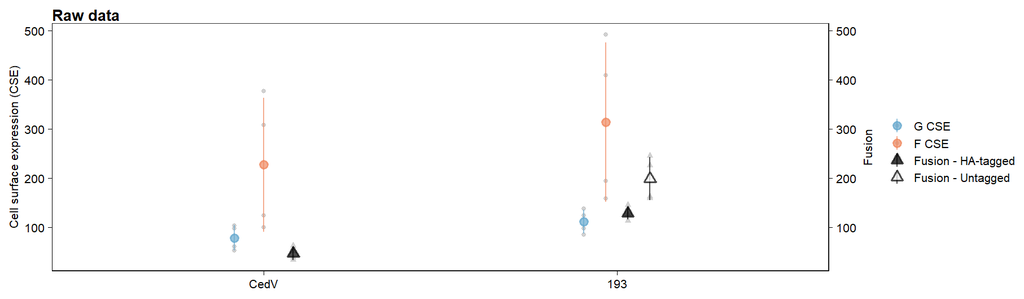

```r
# subset data of interest
Ct = subset(data, experiment == "fusogenicity selected tagged CedV mutants",
             select = -c(experiment))

# calculate mean across technical replicates for figures
Ct_CSE_fusion_aggr = aggregate(value ~ variable + conditions + virus + replicate_bio + tag, data = Ct, mean)

Ct_CSE_fusion_aggr$group = paste0(Ct_CSE_fusion_aggr$tag, "_", Ct_CSE_fusion_aggr$variable)

Ct_CSE_fusion_aggr$group = factor(Ct_CSE_fusion_aggr$group, levels = c("HA_CSE_G", "HA_CSE_F", "HA_fusion_mean", "none_fusion_mean" ))

# plot raw data
ggplot(Ct_CSE_fusion_aggr, aes(x = virus, y = value, color = group, fill = group, shape = group, group = group)) +
  geom_point(size = 1, alpha = 0.7, position=position_dodge(width = 0.25), color = "grey", fill = "grey") +
  stat_summary(fun.data = mean_sdl, fun.args = list(mult = 1), position=position_dodge(width = 0.25), alpha = 0.7) +
  scale_x_discrete(labels = c("CedV", "193")) +
  scale_y_continuous(name = "Cell surface expression (CSE)",
                     sec.axis = sec_axis(~ . * 1, name="Fusion")) +
  scale_shape_manual(values = c(19, 19, 24, 24), labels = c("G CSE", "F CSE", "Fusion - HA-tagged", "Fusion - Untagged")) +
  scale_color_manual(values = c("#67a9cf", "#ef8a62", "black", "black"), labels = c("G CSE", "F CSE", "Fusion - HA-tagged", "Fusion - Untagged")) +
  scale_fill_manual(values = c("#67a9cf", "#ef8a62", "black", "white"), labels = c("G CSE", "F CSE", "Fusion - HA-tagged", "Fusion - Untagged")) +
  ggtheme + theme(axis.title.x = element_blank(), legend.title = element_blank()) +
  ggtitle("Raw data")
```

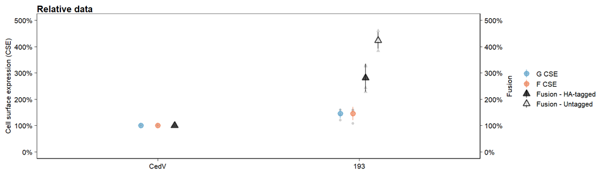

```r
# transform into relative data
Ct_CSE_fusion_aggr$value_relative = NA
for (i in 1:nrow(Ct_CSE_fusion_aggr)){
  Ct_CSE_fusion_aggr$value_relative[i] = Ct_CSE_fusion_aggr$value[i] /
    Ct_CSE_fusion_aggr[Ct_CSE_fusion_aggr$replicate_bio == Ct_CSE_fusion_aggr$replicate_bio[i] &
              Ct_CSE_fusion_aggr$conditions == Ct_CSE_fusion_aggr$conditions[i] &
              Ct_CSE_fusion_aggr$variable == Ct_CSE_fusion_aggr$variable[i] &
              Ct_CSE_fusion_aggr$virus == "CedV", "value"]
}
remove(i)

# plot relative data
ggplot(Ct_CSE_fusion_aggr, aes(x = virus, y = value_relative, color = group, fill = group, shape = group, group = group)) +
  geom_point(size = 1, alpha = 0.7, position=position_dodge(width = 0.25), color = "grey", fill = "grey") +
  stat_summary(fun.data = mean_sdl, fun.args = list(mult = 1), position=position_dodge(width = 0.25), alpha = 0.7) +
  scale_x_discrete(labels = c("CedV", "193")) +
  scale_y_continuous(name = "Cell surface expression (CSE)", limits = c(-0.01, 5), breaks = seq(0, 5, 1), labels = scales::percent,
                     sec.axis = sec_axis(~ . * 1, name="Fusion", breaks = seq(0, 5, 1), labels = scales::percent)) +
  scale_shape_manual(values = c(19, 19, 24, 24), labels = c("G CSE", "F CSE", "Fusion - HA-tagged", "Fusion - Untagged")) +
  scale_color_manual(values = c("#67a9cf", "#ef8a62", "black", "black"), labels = c("G CSE", "F CSE", "Fusion - HA-tagged", "Fusion - Untagged")) +
  scale_fill_manual(values = c("#67a9cf", "#ef8a62", "black", "white"), labels = c("G CSE", "F CSE", "Fusion - HA-tagged", "Fusion - Untagged")) +
  ggtheme + theme(axis.title.x = element_blank(), legend.title = element_blank()) +
  ggtitle("Relative data")
```

### 3.1.2. CedV fusion index

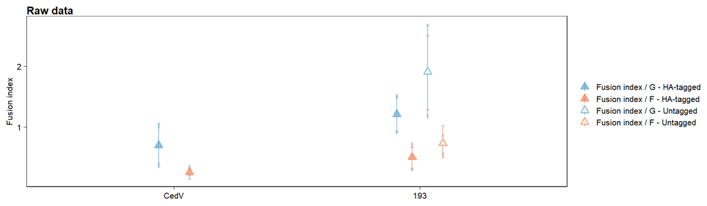

```r
# fusion index
Ct_FI = pivot_wider(names_from = variable, values_from = value, data = Ct)

Ct_FI[Ct_FI$virus == "CedV_193" & is.na(Ct_FI$CSE_G), "CSE_G"] = Ct_FI[Ct_FI$virus == "CedV_193" & !is.na(Ct_FI$CSE_G), "CSE_G"]
Ct_FI[Ct_FI$virus == "CedV_193" & is.na(Ct_FI$CSE_F), "CSE_F"] = Ct_FI[Ct_FI$virus == "CedV_193" & !is.na(Ct_FI$CSE_F), "CSE_F"]

Ct_FI$FI_G = Ct_FI$fusion_mean / Ct_FI$CSE_G
Ct_FI$FI_F = Ct_FI$fusion_mean / Ct_FI$CSE_F
Ct_FI = pivot_longer(cols = c(FI_G, FI_F), names_to = "variable", values_to = "value", data = Ct_FI)
Ct_FI$variable = factor(Ct_FI$variable, levels = c("FI_G", "FI_F"))

# calculate mean across technical replicates for figures
Ct_FI_aggr = aggregate(value ~ variable + conditions + virus + replicate_bio + tag, data = Ct_FI, mean)

Ct_FI_aggr$group = paste0(Ct_FI_aggr$tag, "_", Ct_FI_aggr$variable)

Ct_FI_aggr$group = factor(Ct_FI_aggr$group, levels = c("HA_FI_G", "HA_FI_F", "none_FI_G", "none_FI_F" ))

# plot raw data
ggplot(Ct_FI_aggr, aes(x = virus, y = value, color = group, fill = group, group = group)) +
  geom_point(size = 1, alpha = 0.7, position=position_dodge(width = 0.25), color = "grey", shape = 17) +
  stat_summary(fun.data = mean_sdl, fun.args = list(mult = 1), position=position_dodge(width = 0.25), alpha = 0.7, shape = 24) +
  scale_x_discrete(labels = c("CedV", "193")) +
  scale_y_continuous(name = "Fusion index") +
  scale_color_manual(values = c("#67a9cf", "#ef8a62", "#67a9cf", "#ef8a62"), labels = c("Fusion index / G - HA-tagged", "Fusion index / F - HA-tagged", "Fusion index / G - Untagged", "Fusion index / F - Untagged")) +
  scale_fill_manual(values = c("#67a9cf", "#ef8a62", "white", "white"), labels = c("Fusion index / G - HA-tagged", "Fusion index / F - HA-tagged", "Fusion index / G - Untagged", "Fusion index / F - Untagged")) +
  ggtheme + theme(axis.title.x = element_blank(), legend.title = element_blank()) +
  ggtitle("Raw data")
```

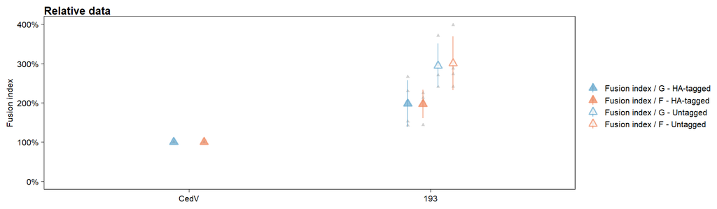

```r
# transform iCto relative data
Ct_FI_aggr$value_relative = NA
for (i in 1:nrow(Ct_FI_aggr)){
  Ct_FI_aggr$value_relative[i] = Ct_FI_aggr$value[i] /
    Ct_FI_aggr[Ct_FI_aggr$replicate_bio == Ct_FI_aggr$replicate_bio[i] &
              Ct_FI_aggr$conditions == Ct_FI_aggr$conditions[i] &
              Ct_FI_aggr$variable == Ct_FI_aggr$variable[i] &
              Ct_FI_aggr$virus == "CedV", "value"]
}
remove(i)

# plot relative data
ggplot(Ct_FI_aggr, aes(x = virus, y = value_relative, color = group, fill = group, group = group)) +
  geom_point(size = 1, alpha = 0.7, position=position_dodge(width = 0.25), color = "grey", shape = 17) +
  stat_summary(fun.data = mean_sdl, fun.args = list(mult = 1), position=position_dodge(width = 0.25), alpha = 0.7, shape = 24) +
  scale_x_discrete(labels = c("CedV", "193")) +
  scale_y_continuous(name = "Fusion index", limits = c(-0.01, 4), breaks = seq(0, 4, 1), labels = scales::percent) +
  scale_color_manual(values = c("#67a9cf", "#ef8a62", "#67a9cf", "#ef8a62"), labels = c("Fusion index / G - HA-tagged", "Fusion index / F - HA-tagged", "Fusion index / G - Untagged", "Fusion index / F - Untagged")) +
  scale_fill_manual(values = c("#67a9cf", "#ef8a62", "white", "white"), labels = c("Fusion index / G - HA-tagged", "Fusion index / F - HA-tagged", "Fusion index / G - Untagged", "Fusion index / F - Untagged")) +
  ggtheme + theme(axis.title.x = element_blank(), legend.title = element_blank()) +
  ggtitle("Relative data")
```

### 3.1.3. NiV CSE and fusion

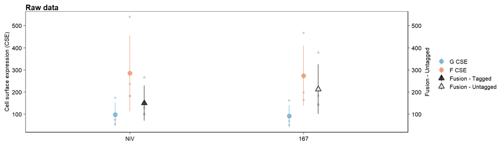

```r
# subset data of interest
Nt = subset(data, experiment == "fusogenicity selected NiV mutants",
             select = -c(experiment))

# calculate mean across technical replicates for figures
Nt_CSE_fusion_aggr = aggregate(value ~ variable + conditions + virus + replicate_bio + tag, data = Nt, mean)

Nt_CSE_fusion_aggr$group = paste0(Nt_CSE_fusion_aggr$tag, "_", Nt_CSE_fusion_aggr$variable)

Nt_CSE_fusion_aggr$group = factor(Nt_CSE_fusion_aggr$group, levels = c("none_CSE_G", "none_CSE_F", "HA_fusion_mean", "none_fusion_mean" ))

# plot raw data
ggplot(Nt_CSE_fusion_aggr, aes(x = virus, y = value, color = group, fill = group, shape = group, group =group)) +
  geom_point(size = 1, alpha = 0.7, position=position_dodge(width = 0.25), color = "grey", fill = "grey") +
  stat_summary(fun.data = mean_sdl, fun.args = list(mult = 1), position=position_dodge(width = 0.25), alpha = 0.7) +
  scale_x_discrete(labels = c("NiV", "167")) +
  scale_y_continuous(name = "Cell surface expression (CSE)",
                     sec.axis = sec_axis(~ . * 1, name="Fusion - Untagged")) +
  scale_shape_manual(values = c(19, 19, 24, 24), labels = c("G CSE", "F CSE", "Fusion - Tagged", "Fusion - Untagged")) +
  scale_color_manual(values = c("#67a9cf", "#ef8a62", "black", "black"), labels = c("G CSE", "F CSE", "Fusion - Tagged", "Fusion - Untagged")) +
  scale_fill_manual(values = c("#67a9cf", "#ef8a62", "black", "white"), labels = c("G CSE", "F CSE", "Fusion - Tagged", "Fusion - Untagged")) +
  ggtheme + theme(axis.title.x = element_blank(), legend.title = element_blank()) +
  ggtitle("Raw data")
```

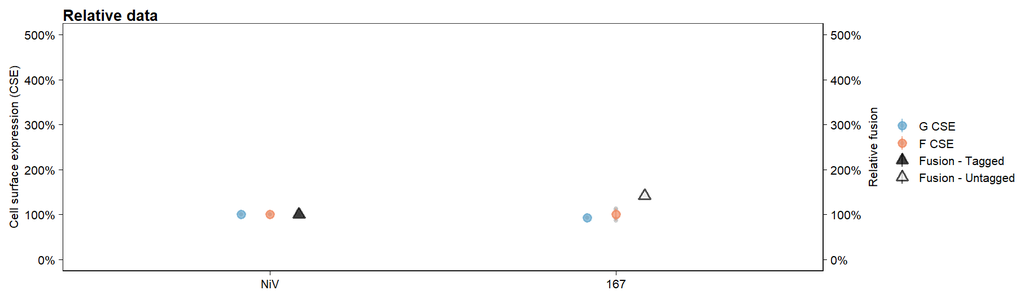

```r
# transform into relative data
Nt_CSE_fusion_aggr$value_relative = NA
for (i in 1:nrow(Nt_CSE_fusion_aggr)){
  Nt_CSE_fusion_aggr$value_relative[i] = Nt_CSE_fusion_aggr$value[i] /
    Nt_CSE_fusion_aggr[Nt_CSE_fusion_aggr$replicate_bio == Nt_CSE_fusion_aggr$replicate_bio[i] &
              Nt_CSE_fusion_aggr$conditions == Nt_CSE_fusion_aggr$conditions[i] &
              Nt_CSE_fusion_aggr$variable == Nt_CSE_fusion_aggr$variable[i] &
              Nt_CSE_fusion_aggr$virus == "NiV", "value"]
}
remove(i)

# plot relative data
ggplot(Nt_CSE_fusion_aggr, aes(x = virus, y = value_relative, color = group, fill = group, shape = group, group =group)) +
  geom_point(size = 1, alpha = 0.7, position=position_dodge(width = 0.25), color = "grey", fill = "grey") +
  stat_summary(fun.data = mean_sdl, fun.args = list(mult = 1), position=position_dodge(width = 0.25), alpha = 0.7) +
  scale_x_discrete(labels = c("NiV", "167")) +
  scale_y_continuous(name = "Cell surface expression (CSE)", limits = c(-0.01, 5), breaks = seq(0, 5, 1), labels = scales::percent,
                     sec.axis = sec_axis(~ . * 1, name="Relative fusion", breaks = seq(0, 5, 1), labels = scales::percent)) +
  scale_shape_manual(values = c(19, 19, 24, 24), labels = c("G CSE", "F CSE", "Fusion - Tagged", "Fusion - Untagged")) +
  scale_color_manual(values = c("#67a9cf", "#ef8a62", "black", "black"), labels = c("G CSE", "F CSE", "Fusion - Tagged", "Fusion - Untagged")) +
  scale_fill_manual(values = c("#67a9cf", "#ef8a62", "black", "white"), labels = c("G CSE", "F CSE", "Fusion - Tagged", "Fusion - Untagged"))  +
  ggtheme + theme(axis.title.x = element_blank(), legend.title = element_blank())+
  ggtitle("Relative data")
```

### 3.1.4. NiV fusion index

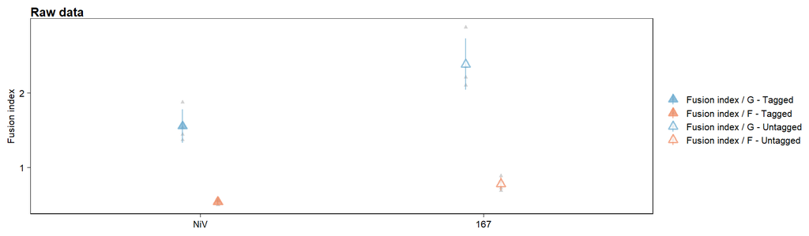

```r
# fusion index
Nt_FI = pivot_wider(names_from = variable, values_from = value, data = Nt)

Nt_FI[Nt_FI$virus == "NiV" & is.na(Nt_FI$CSE_G), "CSE_G"] = Nt_FI[Nt_FI$virus == "NiV" & !is.na(Nt_FI$CSE_G), "CSE_G"]
Nt_FI[Nt_FI$virus == "NiV" & is.na(Nt_FI$CSE_F), "CSE_F"] = Nt_FI[Nt_FI$virus == "NiV" & !is.na(Nt_FI$CSE_F), "CSE_F"]

Nt_FI$FI_G = Nt_FI$fusion_mean / Nt_FI$CSE_G
Nt_FI$FI_F = Nt_FI$fusion_mean / Nt_FI$CSE_F
Nt_FI = pivot_longer(cols = c(FI_G, FI_F), names_to = "variable", values_to = "value", data = Nt_FI)
Nt_FI$variable = factor(Nt_FI$variable, levels = c("FI_G", "FI_F"))

# calculate mean across technical replicates for figures
Nt_FI_aggr = aggregate(value ~ variable + conditions + virus + replicate_bio + tag, data = Nt_FI, mean)

Nt_FI_aggr$group = paste0(Nt_FI_aggr$tag, "_", Nt_FI_aggr$variable)

Nt_FI_aggr$group = factor(Nt_FI_aggr$group, levels = c("HA_FI_G", "HA_FI_F", "none_FI_G", "none_FI_F" ))

# plot raw data
ggplot(Nt_FI_aggr, aes(x = virus, y = value, color = group, fill = group, group =group)) +
  geom_point(size = 1, alpha = 0.7, position=position_dodge(width = 0.25), color = "grey", shape = 17) +
  stat_summary(fun.data = mean_sdl, fun.args = list(mult = 1), position=position_dodge(width = 0.25), alpha = 0.7, shape = 24) +
  scale_x_discrete(labels = c("NiV", "167")) +
  scale_y_continuous(name = "Fusion index") +
  scale_color_manual(values = c("#67a9cf", "#ef8a62", "#67a9cf", "#ef8a62"), labels = c("Fusion index / G - Tagged", "Fusion index / F - Tagged", "Fusion index / G - Untagged", "Fusion index / F - Untagged")) +
  scale_fill_manual(values = c("#67a9cf", "#ef8a62","white", "white"), labels = c("Fusion index / G - Tagged", "Fusion index / F - Tagged", "Fusion index / G - Untagged", "Fusion index / F - Untagged")) +
  ggtheme + theme(axis.title.x = element_blank(), legend.title = element_blank()) +
  ggtitle("Raw data")
```

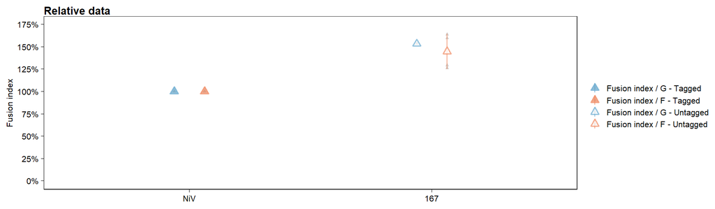

```r
# transform into relative data
Nt_FI_aggr$value_relative = NA
for (i in 1:nrow(Nt_FI_aggr)){
  Nt_FI_aggr$value_relative[i] = Nt_FI_aggr$value[i] /
    Nt_FI_aggr[Nt_FI_aggr$replicate_bio == Nt_FI_aggr$replicate_bio[i] &
              Nt_FI_aggr$conditions == Nt_FI_aggr$conditions[i] &
              Nt_FI_aggr$variable == Nt_FI_aggr$variable[i] &
              Nt_FI_aggr$virus == "NiV", "value"]
}
remove(i)

# plot relative data
ggplot(Nt_FI_aggr, aes(x = virus, y = value_relative, color = group, fill = group, group =group)) +
  geom_point(size = 1, alpha = 0.7, position=position_dodge(width = 0.25), color = "grey", shape = 17) +
  stat_summary(fun.data = mean_sdl, fun.args = list(mult = 1), position=position_dodge(width = 0.25), alpha = 0.7, shape = 24) +
  scale_x_discrete(labels = c("NiV", "167")) +
  scale_y_continuous(name = "Fusion index", limits = c(-0.01,1.75), breaks = seq(0, 1.75, 0.25), labels = scales::percent) +
  scale_color_manual(values = c("#67a9cf", "#ef8a62", "#67a9cf", "#ef8a62"), labels = c("Fusion index / G - Tagged", "Fusion index / F - Tagged", "Fusion index / G - Untagged", "Fusion index / F - Untagged")) +
  scale_fill_manual(values = c("#67a9cf", "#ef8a62","white", "white"), labels = c("Fusion index / G - Tagged", "Fusion index / F - Tagged", "Fusion index / G - Untagged", "Fusion index / F - Untagged")) +
  ggtheme + theme(axis.title.x = element_blank(), legend.title = element_blank())+
  ggtitle("Relative data")
```

### 3.1.5. CedV F CSE with/without tag

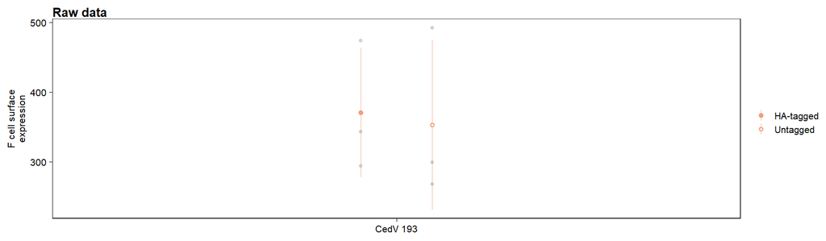

```r
# subset data of interest
Ct_FCSE = subset(data, experiment == "CSE selected tagged CedV mutants",
             select = -c(experiment))

# calculate mean across technical replicates for figures
Ct_FCSE_aggr = aggregate(value ~ variable + conditions + virus + replicate_bio + tag, data = Ct_FCSE, mean)

Ct_FCSE_aggr$group = paste0(Ct_FCSE_aggr$tag, "_", Ct_FCSE_aggr$variable)

Ct_FCSE_aggr$group = factor(Ct_FCSE_aggr$group, levels = c("HA_CSE_F", "none_CSE_F" ))

Ct_FCSE_fusion_aggr = Ct_FCSE_aggr

# plot raw data
ggplot(Ct_FCSE_fusion_aggr, aes(x = virus, y = value,  fill = group, group = group)) +
  geom_point(size = 1, alpha = 0.7, position=position_dodge(width = 0.25), color = "grey", fill = "grey") +
  stat_summary(fun.data = mean_sdl, fun.args = list(mult = 1), position=position_dodge(width = 0.25), alpha = 0.7, color = "#ef8a62", size = 0.25, shape = 21) +
  scale_x_discrete(labels = c("CedV 193")) +
  scale_y_continuous(name = "F cell surface\nexpression") +
  scale_fill_manual(values = c("#ef8a62", "white"), labels = c("HA-tagged", "Untagged")) +
  ggtheme + theme(axis.title.x = element_blank(), legend.title = element_blank()) +
  ggtitle("Raw data")
```

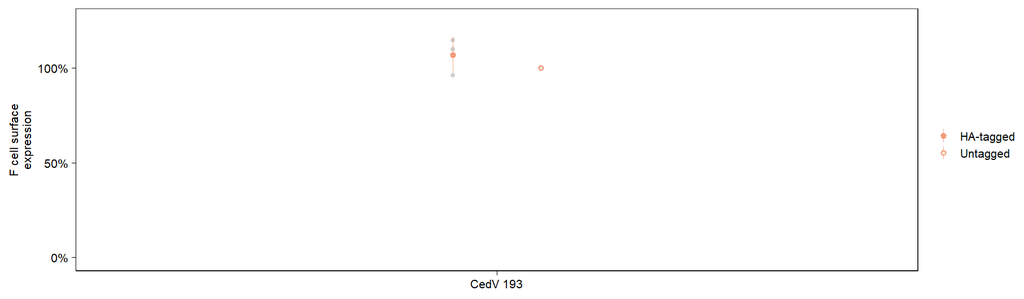

```r
# transform into relative data
Ct_FCSE_fusion_aggr$value_relative = NA
for (i in 1:nrow(Ct_FCSE_fusion_aggr)){
  Ct_FCSE_fusion_aggr$value_relative[i] = Ct_FCSE_fusion_aggr$value[i] /
    Ct_FCSE_fusion_aggr[Ct_FCSE_fusion_aggr$replicate_bio == Ct_FCSE_fusion_aggr$replicate_bio[i] &
              Ct_FCSE_fusion_aggr$variable == Ct_FCSE_fusion_aggr$variable[i] &
              Ct_FCSE_fusion_aggr$tag == "none", "value"]
}
remove(i)

# plot relative data
ggplot(Ct_FCSE_fusion_aggr, aes(x = virus, y = value_relative,  fill = group, group = group)) +
  geom_point(size = 1, alpha = 0.7, position=position_dodge(width = 0.25), color = "grey", fill = "grey") +
  stat_summary(fun.data = mean_sdl, fun.args = list(mult = 1), position=position_dodge(width = 0.25), alpha = 0.7, color = "#ef8a62", size = 0.25, shape = 21) +
  scale_x_discrete(labels = c("CedV 193")) +
  scale_y_continuous(name = "F cell surface\nexpression",limits = c(-0.01, 1.25), breaks = seq(0, 1.25, 0.5), labels = scales::percent) +
  scale_fill_manual(values = c("#ef8a62", "white"), labels = c("HA-tagged", "Untagged")) +
  ggtheme + theme(axis.title.x = element_blank(), legend.title = element_blank())
```

## 3.2. Publication figure

```r
plot_1 = ggplot(Ct_CSE_fusion_aggr, aes(x = virus, y = value_relative, color = group, fill = group, shape = group, group = group)) +
  geom_point(size = 1, alpha = 0.7, position=position_dodge(width = 0.25), color = "grey", fill = "grey") +
  stat_summary(fun.data = mean_sdl, fun.args = list(mult = 1), position=position_dodge(width = 0.25), alpha = 0.7, size = 0.25) +
  scale_x_discrete(labels = c("CedV", "193")) +
  scale_y_continuous(name = "Cell surface\nexpression (CSE)", limits = c(-0.01, 6), breaks = seq(0, 6, 1), labels = scales::percent,
                     sec.axis = sec_axis(~ . * 1, name="Fusion", breaks = seq(0, 6, 1), labels = scales::percent)) +
  scale_shape_manual(values = c(19, 19, 24, 24), labels = c("G CSE", "F CSE", "Fusion - HA-tagged", "Fusion - Untagged")) +
  scale_color_manual(values = c("#67a9cf", "#ef8a62", "black", "black"), labels = c("G CSE", "F CSE", "Fusion - HA-tagged", "Fusion - Untagged")) +
  scale_fill_manual(values = c("#67a9cf", "#ef8a62", "black", "white"), labels = c("G CSE", "F CSE", "Fusion - HA-tagged", "Fusion - Untagged")) +
  ggtheme + theme(axis.title.x = element_blank(), legend.title = element_blank()) +
  theme(axis.text.x = element_blank(), axis.text.y.right = element_blank(), axis.title.y.right = element_blank())

plot_2 = ggplot(Ct_FI_aggr, aes(x = virus, y = value_relative, color = group, fill = group, group = group)) +
  geom_point(size = 1, alpha = 0.7, position=position_dodge(width = 0.25), color = "grey", shape = 17) +
  stat_summary(fun.data = mean_sdl, fun.args = list(mult = 1), position=position_dodge(width = 0.25), alpha = 0.7, shape = 24, size = 0.25) +
  scale_x_discrete(labels = c("CedV", "193")) +
  scale_y_continuous(name = "Fusion\nindex (FI)", limits = c(-0.01, 6), breaks = seq(0, 6, 1), labels = scales::percent) +
  scale_color_manual(values = c("#67a9cf", "#ef8a62", "#67a9cf", "#ef8a62"), labels = c("Fusion index / G - HA-tagged", "Fusion index / F - HA-tagged", "Fusion index / G - Untagged", "Fusion index / F - Untagged")) +
  scale_fill_manual(values = c("#67a9cf", "#ef8a62", "white", "white"), labels = c("Fusion index / G - HA-tagged", "Fusion index / F - HA-tagged", "Fusion index / G - Untagged", "Fusion index / F - Untagged")) +
  ggtheme + theme(axis.title.x = element_blank(), legend.title = element_blank())

plot_3 = ggplot(Nt_CSE_fusion_aggr, aes(x = virus, y = value_relative, color = group, fill = group, shape = group, group =group)) +
  geom_point(size = 1, alpha = 0.7, position=position_dodge(width = 0.25), color = "grey", fill = "grey") +
  stat_summary(fun.data = mean_sdl, fun.args = list(mult = 1), position=position_dodge(width = 0.25), alpha = 0.7, size = 0.25) +
  scale_x_discrete(labels = c("NiV", "167")) +
  scale_y_continuous(name = "Cell surface\nexpression (CSE)", limits = c(-0.01, 6), breaks = seq(0, 6, 1), labels = scales::percent,
                     sec.axis = sec_axis(~ . * 1, name="Relative fusion", breaks = seq(0, 6, 1), labels = scales::percent)) +
  scale_shape_manual(values = c(19, 19, 24, 24), labels = c("G CSE", "F CSE", "Fusion - Tagged", "Fusion - Untagged")) +
  scale_color_manual(values = c("#67a9cf", "#ef8a62", "black", "black"), labels = c("G CSE", "F CSE", "Fusion - Tagged", "Fusion - Untagged")) +
  scale_fill_manual(values = c("#67a9cf", "#ef8a62", "black", "white"), labels = c("G CSE", "F CSE", "Fusion - Tagged", "Fusion - Untagged"))  +
  ggtheme + theme(axis.title.x = element_blank(), legend.title = element_blank()) +
  theme(axis.text.x = element_blank(), axis.text.y.left = element_blank(), axis.title.y.left = element_blank(), legend.position = "none")

plot_4 = ggplot(Nt_FI_aggr, aes(x = virus, y = value_relative, color = group, fill = group, group =group)) +
  geom_point(size = 1, alpha = 0.7, position=position_dodge(width = 0.25), color = "grey", shape = 17) +
  stat_summary(fun.data = mean_sdl, fun.args = list(mult = 1), position=position_dodge(width = 0.25), alpha = 0.7, shape = 24, size = 0.25) +
  scale_x_discrete(labels = c("NiV", "167")) +
  scale_y_continuous(name = "Fusion\nindex (FI)", limits = c(-0.01, 6), breaks = seq(0, 6, 1), labels = scales::percent) +
  scale_color_manual(values = c("#67a9cf", "#ef8a62", "#67a9cf", "#ef8a62"), labels = c("Fusion index / G - Tagged", "Fusion index / F - Tagged", "Fusion index / G - Untagged", "Fusion index / F - Untagged")) +
  scale_fill_manual(values = c("#67a9cf", "#ef8a62","white", "white"), labels = c("Fusion index / G - Tagged", "Fusion index / F - Tagged", "Fusion index / G - Untagged", "Fusion index / F - Untagged")) +
  ggtheme + theme(axis.title.x = element_blank(), legend.title = element_blank()) +
  theme(axis.title.y = element_blank(), axis.text.y = element_blank(), legend.position = "none")

# ASSEMBLE

plot_left = (plot_1 + plot_2) + plot_layout(ncol = 1, heights = c(1, 1))
plot_right = (plot_3 + plot_4) + plot_layout(ncol = 1, heights = c(1, 1))

# complete assemblage
patchwork = (plot_left | plot_right) +
  plot_layout(guides = "collect") & theme(legend.position = "right", legend.box.just = "left") &
  theme(plot.tag = element_text(size = 8, face = "bold"))

# print figure
# patchwork

# save figure
ggsave(paste0("export/CedV_fusion_", "Fig4_1", ".pdf"),
       width = 15.5, height = 8, units = "cm", dpi = 600)

# complete assemblage
patchwork = (plot_left | plot_right) +
  plot_layout(guides = "collect") & theme(legend.position = "right", legend.box.just = "left") &
  theme(plot.tag = element_text(size = 8, face = "bold"), legend.position = "none")

# print figure
# patchwork

# save figure
ggsave(paste0("export/CedV_fusion_", "Fig4_1_no_leg", ".pdf"),
       width = 10, height = 8, units = "cm", dpi = 600)

# plot relative data
plot_bottom = ggplot(Ct_FCSE_fusion_aggr, aes(x = virus, y = value_relative,  fill = group, group = group)) +
  geom_point(size = 1, alpha = 0.7, position=position_dodge(width = 0.25), color = "grey", fill = "grey") +
  stat_summary(fun.data = mean_sdl, fun.args = list(mult = 1), position=position_dodge(width = 0.25), alpha = 0.7, color = "#ef8a62", size = 0.25, shape = 21) +
  scale_x_discrete(labels = c("CedV 193")) +
  scale_y_continuous(name = "F cell surface\nexpression",limits = c(-0.01, 1.25), breaks = seq(0, 1.25, 0.5), labels = scales::percent) +
  scale_fill_manual(values = c("#ef8a62", "white"), labels = c("HA-tagged", "Untagged")) +
  ggtheme + theme(axis.title.x = element_blank(), legend.title = element_blank())

# print figure
# plot_bottom

ggsave(paste0("export/CedV_fusion_", "Fig4_2", ".pdf"),
       width = 8, height = 3, units = "cm", dpi = 600)
```

## 3.3. Statistical analyses

### 3.3.1. CedV

Test 1: fusion; Test 2: fusion index / F; Test 3: fusion index / G

Homo: under the homoscedasticity assumption; Hetero: under the heteroscedasticity assumption

```r
Ct$group = paste0(Ct$virus, "_", Ct$tag)
Ct$group = factor(Ct$group, levels = c("CedV_HA", "CedV_193_none", "CedV_193_HA"))

Ct_FI$group = paste0(Ct_FI$virus, "_", Ct_FI$tag)
Ct_FI$group = factor(Ct_FI$group, levels = c("CedV_HA", "CedV_193_none", "CedV_193_HA"))

# Tests

test_1_homo = lme(value ~ group, random = ~ 1|replicate_bio,
                    data = subset(Ct, variable == "fusion_mean"),
                    method = "ML")

test_1_hetero = lme(value ~ group, random = ~ 1|replicate_bio,
                    data = subset(Ct, variable == "fusion_mean"),
                    method = "ML",
                    weights = varIdent(form = ~ 1|group))

anova(test_1_homo, test_1_hetero)
```

```
##               Model df      AIC      BIC     logLik   Test  L.Ratio p-value
## test_1_homo       1  5 218.8301 224.7204 -104.41506
## test_1_hetero     2  7 198.6583 206.9047  -92.32916 1 vs 2 24.17181  <.0001
```

```r
anova(test_1_hetero)
```

```
##             numDF denDF  F-value p-value
## (Intercept)     1    18 139.3902  <.0001
## group           2    18 536.3636  <.0001
```

```r
test_2_homo = lme(value ~ group, random = ~ 1|replicate_bio,
                    data = subset(Ct_FI, variable == "FI_F"),
                    method = "ML")

test_2_hetero = lme(value ~ group, random = ~ 1|replicate_bio,
                    data = subset(Ct_FI, variable == "FI_F"),
                    method = "ML",
                    weights = varIdent(form = ~ 1|group))

anova(test_2_homo, test_2_hetero)
```

```
##               Model df       AIC       BIC   logLik   Test   L.Ratio p-value
## test_2_homo       1  5 -24.65088 -18.76061 17.32544
## test_2_hetero     2  7 -20.96910 -12.72272 17.48455 1 vs 2 0.3182196  0.8529
```

```r
anova(test_2_hetero)
```

```
##             numDF denDF  F-value p-value
## (Intercept)     1    18 31.05607  <.0001
## group           2    18 42.95643  <.0001
```

```r
test_3_homo = lme(value ~ group, random = ~ 1|replicate_bio,
                    data = subset(Ct_FI, variable == "FI_G"),
                    method = "ML")

test_3_hetero = lme(value ~ group, random = ~ 1|replicate_bio,
                    data = subset(Ct_FI, variable == "FI_G"),
                    method = "ML",
                    weights = varIdent(form = ~ 1|group))

anova(test_3_homo, test_2_hetero)
```

```
##               Model df      AIC       BIC    logLik   Test L.Ratio p-value
## test_3_homo       1  5  16.3715  22.26177 -3.185751
## test_2_hetero     2  7 -20.9691 -12.72272 17.484548 1 vs 2 41.3406  <.0001
```

```r
anova(test_3_hetero)
```

```
##             numDF denDF   F-value p-value
## (Intercept)     1    18  43.94998  <.0001
## group           2    18 155.80646  <.0001
```

```r
tukey_1 = lsmeans(test_1_hetero, pairwise ~ group, adjust = "tukey")
tukey_2 = lsmeans(test_2_hetero, pairwise ~ group, adjust = "tukey")
tukey_3 = lsmeans(test_3_hetero, pairwise ~ group, adjust = "tukey")

# Store and format results

stats = as.data.frame(rbind(
  anova(test_1_hetero)[2, ],
  anova(test_2_hetero)[2, ],
  anova(test_3_hetero)[2, ]))

stats$variable = c("Fusion",
                       "Fusion index / F",
                       "Fusion index / G")
stats$comparison = NA

stats$test = "Wald test (F-value)"

stats$Value = NA
stats$Std.Error = NA

stats = stats[, c("variable", "comparison", "test", "F-value", "p-value", "Value", "Std.Error")]
colnames(stats) = c("Variable", "Comparison", "Test", "Statistics", "p_value", "Estimate", "se")

tukey = rbind(
  as.data.frame(tukey_1[[2]]),
  as.data.frame(tukey_2[[2]]),
  as.data.frame(tukey_3[[2]]))

n_comp = 3

tukey$variable = c(rep("Fusion", n_comp),
                       rep("Fusion index / F", n_comp),
                       rep("Fusion index / G", n_comp))

tukey$test = "Tukey pairwise Comparison (t-ratio)"

tukey = tukey[, c("variable", "contrast", "test", "t.ratio", "p.value", "estimate", "SE")]
colnames(tukey) = c("Variable", "Comparison", "Test", "Statistics", "p_value", "Estimate", "se")

stats = rbind(stats, tukey)

stats = stats[order(stats$Variable), ]

stats = stats %>% mutate_if(is.numeric, round, digits = 3)

stats[stats$p_value < 0.001, "p_value"] = "< 0.001"

stats$Estimate = paste0(stats$Estimate, " ± ", stats$se)

stats = stats[, c("Variable", "Comparison", "Test", "Statistics", "p_value", "Estimate")]
stats[stats$Estimate == ("NA ± NA"), "Estimate"] = NA

kable(stats, digits = 3, row.names = F, caption =
        "Analysis of the effect of HA-tag on fusion in CedV mutants. The effect of virus genotype on the variable of interest was quantified with a Wald test (reporting an F-value) obtained from a mixed model allowing for heterogeneous variance among groups (here tagged vs untagged) and including a random effect representing the experimental session. As this experiment included more than two groups, post-hoc pairwise comparisons between genotypes were then performed using a Tukey test (reporting a t-ratio). Fusion was quantified as number of nuclei included in syncytia, and fusion indices as number of nuclei included in syncytia / flow-cytometry signal."
      ) %>%
  kable_styling(bootstrap_options = c("striped", "hover", "condensed"))
```

Analysis of the effect of HA-tag on fusion in CedV mutants. The effect of virus genotype on the variable of interest was quantified with a Wald test (reporting an F-value) obtained from a mixed model allowing for heterogeneous variance among groups (here tagged vs untagged) and including a random effect representing the experimental session. As this experiment included more than two groups, post-hoc pairwise comparisons between genotypes were then performed using a Tukey test (reporting a t-ratio). Fusion was quantified as number of nuclei included in syncytia, and fusion indices as number of nuclei included in syncytia / flow-cytometry signal.

| Variable | Comparison | Test | Statistics | p_value | Estimate |
| --- | --- | --- | --- | --- | --- |
| Fusion |  | Wald test (F-value) | 536.364 | < 0.001 |  |
| Fusion | CedV_HA - CedV_193_none | Tukey pairwise Comparison (t-ratio) | -14.020 | < 0.001 | -151.65 ± 10.817 |
| Fusion | CedV_HA - CedV_193_HA | Tukey pairwise Comparison (t-ratio) | -30.538 | < 0.001 | -81.45 ± 2.667 |
| Fusion | CedV_193_none - CedV_193_HA | Tukey pairwise Comparison (t-ratio) | 6.410 | < 0.001 | 70.2 ± 10.952 |
| Fusion index / F |  | Wald test (F-value) | 42.956 | < 0.001 |  |
| Fusion index / F | CedV_HA - CedV_193_none | Tukey pairwise Comparison (t-ratio) | -9.252 | < 0.001 | -0.478 ± 0.052 |
| Fusion index / F | CedV_HA - CedV_193_HA | Tukey pairwise Comparison (t-ratio) | -5.288 | < 0.001 | -0.248 ± 0.047 |
| Fusion index / F | CedV_193_none - CedV_193_HA | Tukey pairwise Comparison (t-ratio) | 4.753 | < 0.001 | 0.231 ± 0.048 |
| Fusion index / G |  | Wald test (F-value) | 155.806 | < 0.001 |  |
| Fusion index / G | CedV_HA - CedV_193_none | Tukey pairwise Comparison (t-ratio) | -7.971 | < 0.001 | -1.219 ± 0.153 |
| Fusion index / G | CedV_HA - CedV_193_HA | Tukey pairwise Comparison (t-ratio) | -16.738 | < 0.001 | -0.515 ± 0.031 |
| Fusion index / G | CedV_193_none - CedV_193_HA | Tukey pairwise Comparison (t-ratio) | 4.643 | 0.001 | 0.704 ± 0.152 |

### 3.3.2. NiV

Test 1: fusion; Test 2: fusion index / F; Test 3: fusion index / G

Homo: under the homoscedasticity assumption; Hetero: under the heteroscedasticity assumption

```r
Nt$group = paste0(Nt$virus, "_", Nt$tag)
Nt$group = factor(Nt$group, levels = c("NiV_HA", "NiV_none", "NiV_167_none"))

Nt_FI$group = paste0(Nt_FI$virus, "_", Nt_FI$tag)
Nt_FI$group = factor(Nt_FI$group, levels = c("NiV_HA", "NiV_none", "NiV_167_none"))

# Tests

test_1_homo = lme(value ~ group, random = ~ 1|replicate_bio,
                    data = subset(Nt, variable == "fusion_mean"),
                    method = "ML")

test_1_hetero = lme(value ~ group, random = ~ 1|replicate_bio,
                    data = subset(Nt, variable == "fusion_mean"),
                    method = "ML",
                    weights = varIdent(form = ~ 1|group))

anova(test_1_homo, test_1_hetero)
```

```
##               Model df      AIC      BIC    logLik   Test  L.Ratio p-value
## test_1_homo       1  4 163.6481 166.7384 -77.82403
## test_1_hetero     2  5 161.7152 165.5782 -75.85761 1 vs 2 3.932836  0.0474
```

```r
anova(test_1_hetero)
```

```
##             numDF denDF  F-value p-value
## (Intercept)     1    11 16.70375  0.0018
## group           1    11 31.61456  0.0002
```

```r
test_2_homo = lme(value ~ group, random = ~ 1|replicate_bio,
                    data = subset(Nt_FI, variable == "FI_F" & !is.na(value)),
                    method = "ML")

test_2_hetero = lme(value ~ group, random = ~ 1|replicate_bio,
                    data = subset(Nt_FI, variable == "FI_F" & !is.na(value)),
                    method = "ML",
                    weights = varIdent(form = ~ 1|group))

anova(test_2_homo, test_2_hetero)
```

```
##               Model df       AIC       BIC   logLik   Test  L.Ratio p-value
## test_2_homo       1  4 -31.17267 -28.08231 19.58633
## test_2_hetero     2  5 -37.43964 -33.57669 23.71982 1 vs 2 8.266972   0.004
```

```r
anova(test_2_hetero)
```

```
##             numDF denDF   F-value p-value
## (Intercept)     1    11 1873.8651  <.0001
## group           1    11   39.6594   1e-04
```

```r
test_3_homo = lme(value ~ group, random = ~ 1|replicate_bio,
                    data = subset(Nt_FI, variable == "FI_G" & !is.na(value)),
                    method = "ML")

test_3_hetero = lme(value ~ group, random = ~ 1|replicate_bio,
                    data = subset(Nt_FI, variable == "FI_G" & !is.na(value)),
                    method = "ML",
                    weights = varIdent(form = ~ 1|group))

anova(test_3_homo, test_2_hetero)
```

```
##               Model df       AIC       BIC    logLik   Test  L.Ratio p-value
## test_3_homo       1  4   8.59074  11.68110 -0.295372
## test_2_hetero     2  5 -37.43964 -33.57669 23.719819 1 vs 2 48.03038  <.0001
```

```r
anova(test_3_hetero)
```

```
##             numDF denDF   F-value p-value
## (Intercept)     1    11 223.79396  <.0001
## group           1    11  62.21531  <.0001
```

```r
# Store and format results

stats = as.data.frame(rbind(
  summary(test_1_hetero)$tTable[2, ],
  summary(test_2_hetero)$tTable[2, ],
  summary(test_3_hetero)$tTable[2, ]))

stats$variable = c("Fusion",
                       "Fusion index / F",
                       "Fusion index / G")

stats$comparison = "NiV167 - NiV"

stats$test = "Wald test (t-ratio)"

stats = stats[, c("variable", "comparison", "test", "t-value", "p-value", "Value", "Std.Error")]
colnames(stats) = c("Variable", "Comparison", "Test", "Statistics", "p-value", "Estimate", "se")

stats = stats[order(stats$Variable), ]

stats = stats %>% mutate_if(is.numeric, round, digits = 3)

stats[stats$p_value < 0.001, "p-value"] = "< 0.001"

stats$Estimate = paste0(stats$Estimate, " ± ", stats$se)

stats = stats[, c("Variable", "Comparison", "Test", "Statistics", "p-value", "Estimate")]

kable(stats, digits = 3, row.names = F, caption =
        "Comparison of fusion indices among NiV mutants. The effect of virus genotype on the variable of interest was quantified with a Wald test (reporting a t-value) obtained from a mixed model allowing for heterogeneous variance among groups (here NiV mutants) and including a random effect representing the experimental session. Fusion was quantified as number of nuclei included in syncytia, and fusion indices as number of nuclei included in syncytia / flow-cytometry signal."
      ) %>%
  kable_styling(bootstrap_options = c("striped", "hover", "condensed"))
```

Comparison of fusion indices among NiV mutants. The effect of virus genotype on the variable of interest was quantified with a Wald test (reporting a t-value) obtained from a mixed model allowing for heterogeneous variance among groups (here NiV mutants) and including a random effect representing the experimental session. Fusion was quantified as number of nuclei included in syncytia, and fusion indices as number of nuclei included in syncytia / flow-cytometry signal.

| Variable | Comparison | Test | Statistics | p-value | Estimate |
| --- | --- | --- | --- | --- | --- |
| Fusion | NiV167 - NiV | Wald test (t-ratio) | 5.623 | 0 | 62.8 ± 11.169 |
| Fusion index / F | NiV167 - NiV | Wald test (t-ratio) | 6.298 | 0 | 0.238 ± 0.038 |
| Fusion index / G | NiV167 - NiV | Wald test (t-ratio) | 7.888 | 0 | 0.829 ± 0.105 |

### 3.3.3. CedV F CSE

Homo: under the homoscedasticity assumption; Hetero: under the heteroscedasticity assumption

```r
# Tests

test_1_homo = lme(value ~ tag, random = ~ 1|replicate_bio,
                    data = Ct_FCSE,
                    method = "ML")

test_1_hetero = lme(value ~ tag, random = ~ 1|replicate_bio,
                    data = Ct_FCSE,
                    method = "ML",
                    weights = varIdent(form = ~ 1|tag))

anova(test_1_homo, test_1_hetero)
```

```
##               Model df      AIC      BIC    logLik   Test  L.Ratio p-value
## test_1_homo       1  4 122.9912 124.9308 -57.49558
## test_1_hetero     2  5 121.5446 123.9691 -55.77228 1 vs 2 3.446602  0.0634
```

```r
anova(test_1_homo)
```

```
##             numDF denDF  F-value p-value
## (Intercept)     1     8 43.25349  0.0002
## tag             1     8  2.93904  0.1248
```

```r
# Store and format results

stats = as.data.frame(rbind(
  summary(test_1_hetero)$tTable[2, ]))

stats$variable = c("F cell surface expression")

stats$comparison = "CedV193(HA) - CedV193"

stats$test = "Wald test (t-ratio)"

stats = stats[, c("variable", "comparison", "test", "t-value", "p-value", "Value", "Std.Error")]
colnames(stats) = c("Variable", "Comparison", "Test", "Statistics", "p-value", "Estimate", "se")

stats = stats[order(stats$Variable), ]

stats = stats %>% mutate_if(is.numeric, round, digits = 3)

stats[stats$p_value < 0.001, "p-value"] = "< 0.001"

stats$Estimate = paste0(stats$Estimate, " ± ", stats$se)

stats = stats[, c("Variable", "Comparison", "Test", "Statistics", "p-value", "Estimate")]

kable(stats, digits = 3, row.names = F, caption =
        "Analysis of the effect of HA-tag of CedV G193 on F cell surface expression (CSE). The effect of virus genotype on the variable of interest was quantified with a Wald test (reporting a t-value) obtained from a mixed model allowing for heterogeneous variance among groups (here tagged vs untagged) and including a random effect representing the experimental session. Cell surface expression was quantified as flow-cytometry signal. "
      ) %>%
  kable_styling(bootstrap_options = c("striped", "hover", "condensed"))
```

Analysis of the effect of HA-tag of CedV G193 on F cell surface expression (CSE). The effect of virus genotype on the variable of interest was quantified with a Wald test (reporting a t-value) obtained from a mixed model allowing for heterogeneous variance among groups (here tagged vs untagged) and including a random effect representing the experimental session. Cell surface expression was quantified as flow-cytometry signal.

[output not shown]

```r
# clean working space
remove(Ct, Nt, Ct_FCSE_fusion_aggr, Nt_FCSE_fusion_aggr, Ct_FI, Nt_FI, Ct_FI_aggr, Nt_FI_aggr, Ct_FCSE, Ct_FCSE_aggr)
remove(plot_1, plot_2, plot_3, plot_4, plot_left, plot_right, plot_bottom, patchwork)
remove(test_1_hetero, test_1_homo, test_2_hetero, test_2_homo, test_3_hetero, test_3_homo, stats, tukey, tukey_1, tukey_2, tukey_3)
```

# 4. Avidity selected mutants

## 4.1. Data exploration

### 4.1.1. Avidity

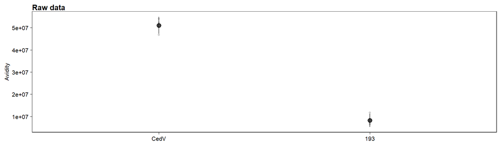

```r
# subset data of interest
Cav = subset(data, experiment == "avidity selected tagged CedV mutants",
             select = -c(experiment))

Cav = as.data.frame(pivot_wider(Cav, names_from = variable, values_from = value))

Cav$avidity = Cav$CoIP_GHA / Cav$Lysate_GHA * Cav$IP_FFLAG

#Cav$avidity = NA
#Cav[Cav$virus == "CedV", "avidity"] = Cav[Cav$virus == "CedV", "CoIP_GHA"] /
 # Cav[Cav$virus == "CedV", "Lysate_GHA"] * Cav[Cav$virus == "CedV", "IP_FFLAG"]

# plot raw data
ggplot(Cav, aes(x = virus, y = avidity)) +
  geom_point(size = 1, alpha = 0.7, position=position_dodge(width = 0.25), color = "grey") +
  stat_summary(fun.data = mean_sdl, fun.args = list(mult = 1), position=position_dodge(width = 0.25), alpha = 0.7) +
  scale_y_continuous(name = "Avidity") +
  scale_x_discrete(labels = c("CedV", "193")) +
  ggtheme + theme(axis.title.x = element_blank(), legend.title = element_blank()) +
  ggtitle("Raw data")
```

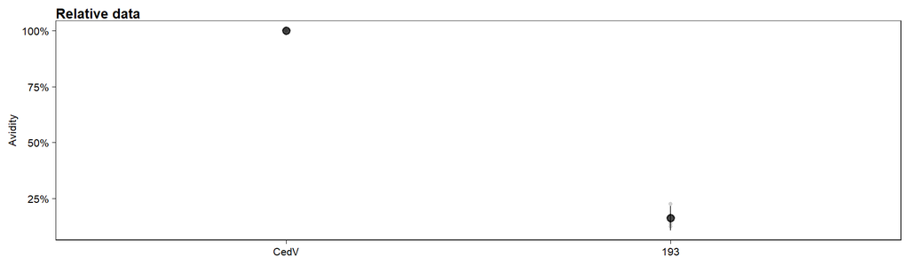

```r
# transform into relative data
Cav$value_relative = NA
for (i in 1:nrow(Cav)){
  Cav$value_relative[i] = Cav$avidity[i] /
    Cav[Cav$replicate_bio == Cav$replicate_bio[i] &
              Cav$virus == "CedV", "avidity"]
}
remove(i)

# plot relative data
ggplot(Cav, aes(x = virus, y = value_relative)) +
  geom_point(size = 1, alpha = 0.7, position=position_dodge(width = 0.25), color = "grey") +
  stat_summary(fun.data = mean_sdl, fun.args = list(mult = 1), position=position_dodge(width = 0.25), alpha = 0.7) +
  scale_y_continuous(name = "Avidity", labels = scales::percent) +
  scale_x_discrete(labels = c("CedV", "193")) +
  ggtheme + theme(axis.title.x = element_blank(), legend.title = element_blank())+
  ggtitle("Relative data")
```

### 4.1.2. Polymers

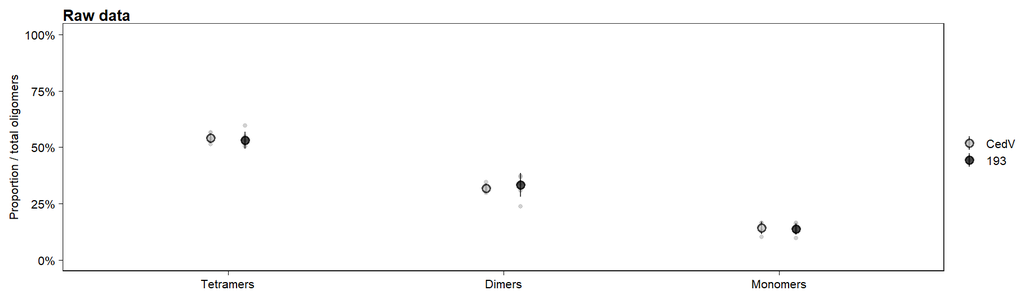

```r
# subset data of interest
Cpo = subset(data, experiment == "polymer selected CedV mutants",
             select = -c(experiment))

Cpo = as.data.frame(pivot_wider(Cpo, names_from = variable, values_from = value))

Cpo$prop_Tetramer = Cpo$Tetramer / (Cpo$Tetramer + Cpo$Dimer + Cpo$Monomer1 + Cpo$Monomer2)
Cpo$prop_Dimer = Cpo$Dimer / (Cpo$Tetramer + Cpo$Dimer + Cpo$Monomer1 + Cpo$Monomer2)
Cpo$prop_Monomer = (Cpo$Monomer1 + Cpo$Monomer2) / (Cpo$Tetramer + Cpo$Dimer + Cpo$Monomer1 + Cpo$Monomer2)

Cpo = as.data.frame(pivot_longer(Cpo, cols = starts_with("prop"), names_to = "variable", values_to = "value"))

Cpo$variable = factor(Cpo$variable, levels = c("prop_Tetramer","prop_Dimer","prop_Monomer"))

#Cav$avidity = NA
#Cav[Cav$virus == "CedV", "avidity"] = Cav[Cav$virus == "CedV", "CoIP_GHA"] /
 # Cav[Cav$virus == "CedV", "Lysate_GHA"] * Cav[Cav$virus == "CedV", "IP_FFLAG"]

# plot raw data
ggplot(Cpo, aes(x = variable, y = value, fill = virus, group = virus)) +
  geom_point(size = 1, alpha = 0.7, position=position_dodge(width = 0.25), color = "grey") +
  stat_summary(fun.data = mean_sdl, fun.args = list(mult = 1), position=position_dodge(width = 0.25), alpha = 0.7, shape = 21) +
  scale_y_continuous(name = "Proportion / total oligomers", labels = scales::percent, limits = c(0,1)) +
  scale_x_discrete(labels = c("Tetramers", "Dimers", "Monomers")) +
  scale_fill_manual(values = c("grey", "black"), labels = c("CedV", "193")) +
  ggtheme + theme(axis.title.x = element_blank(), legend.title = element_blank()) +
  ggtitle("Raw data")
```

## 4.2. Publication figure

```r
plot_1 = ggplot(Cpo, aes(x = variable, y = value, fill = virus, group = virus)) +
  geom_point(size = 1, alpha = 0.7, position=position_dodge(width = 0.25), color = "grey") +
  stat_summary(fun.data = mean_sdl, fun.args = list(mult = 1), position=position_dodge(width = 0.25), alpha = 0.7, shape = 21) +
  scale_y_continuous(name = "Proportion / total oligomers", labels = scales::percent, limits = c(0,1)) +
  scale_x_discrete(labels = c("Tetramers", "Dimers", "Monomers")) +
  scale_fill_manual(values = c("grey", "black"), labels = c("CedV", "193")) +
  ggtheme + theme(axis.title.x = element_blank(), legend.title = element_blank()) +
  theme(legend.position = c(0.99, 1.03), legend.justification = c(1, 1))

# print
# plot_1

ggsave(paste0("export/CedV_fusion_", "Fig5_1", ".pdf"),
       width = 7, height = 5, units = "cm", dpi = 600)

# Figure 2.e
plot_2 = ggplot(Cav, aes(x = virus, y = value_relative)) +
  geom_point(size = 1, alpha = 0.7, position=position_dodge(width = 0.25), color = "grey") +
  stat_summary(fun.data = mean_sdl, fun.args = list(mult = 1), position=position_dodge(width = 0.25), alpha = 0.7) +
  scale_y_continuous(name = "Avidity", labels = scales::percent, limits = c(0, 1)) +
  scale_x_discrete(labels = c("CedV", "193")) +
  ggtheme + theme(axis.title.x = element_blank(), legend.title = element_blank())

# print
# plot_2

ggsave(paste0("export/CedV_fusion_", "Fig5_2", ".pdf"),
       width = 5, height = 5, units = "cm", dpi = 600)
```

## 4.3. Statistical analyses

Homo: under the homoscedasticity assumption; Hetero: under the heteroscedasticity assumption

```r
# Tests

test_1_homo = lme(avidity ~ virus, random = ~ 1|replicate_bio,
                    data = Cav,
                    method = "ML")

test_1_hetero = lme(avidity ~ virus, random = ~ 1|replicate_bio,
                    data = Cav,
                    method = "ML",
                    weights = varIdent(form = ~ 1|virus))

anova(test_1_homo, test_1_hetero)
```

```
##               Model df      AIC      BIC    logLik   Test   L.Ratio p-value
## test_1_homo       1  4 202.7886 201.9556 -97.39430
## test_1_hetero     2  5 204.6039 203.5627 -97.30193 1 vs 2 0.1847346  0.6673
```

```r
anova(test_1_homo)
```

```
##             numDF denDF  F-value p-value
## (Intercept)     1     2 347.1597  0.0029
## virus           1     2 342.4467  0.0029
```

```r
# Store and format results

stats = as.data.frame(rbind(
  summary(test_1_hetero)$tTable[2, ]))

stats$variable = c("F-G avidity")

stats$comparison = "CedV193 - CedV"

stats$test = "Wald test (t-ratio)"

stats = stats[, c("variable", "comparison", "test", "t-value", "p-value", "Value", "Std.Error")]
colnames(stats) = c("Variable", "Comparison", "Test", "Statistics", "p-value", "Estimate", "se")

stats = stats[order(stats$Variable), ]

stats = stats %>% mutate_if(is.numeric, round, digits = 3)

stats[stats$p_value < 0.001, "p-value"] = "< 0.001"

stats$Estimate = paste0(stats$Estimate, " ± ", stats$se)

stats = stats[, c("Variable", "Comparison", "Test", "Statistics", "p-value", "Estimate")]

kable(stats, digits = 3, row.names = F, caption =
        "Comparison of F G avidity between CedV G and CedV G193. The effect of virus genotype on the variable of interest was quantified with a Wald test (reporting a t-value) obtained from a mixed model allowing for heterogeneous variance among groups (here G genotype) and including a random effect representing the experimental session. Avidity was quantified as densitometry signal. "
      ) %>%
  kable_styling(bootstrap_options = c("striped", "hover", "condensed"))
```

Comparison of F G avidity between CedV G and CedV G193. The effect of virus genotype on the variable of interest was quantified with a Wald test (reporting a t-value) obtained from a mixed model allowing for heterogeneous variance among groups (here G genotype) and including a random effect representing the experimental session. Avidity was quantified as densitometry signal.

| Variable | Comparison | Test | Statistics | p-value | Estimate |
| --- | --- | --- | --- | --- | --- |
| F-G avidity | CedV193 - CedV | Wald test (t-ratio) | -18.505 | 0.003 | -42775149.767 ± 2311506.383 |

```r
# clean working space
remove(Cav, Cpo)
remove(plot_1, plot_2)
remove(test_1_hetero, test_1_homo, stats)
```

# 5. Tagged NiV and HeV mutants

## 5.1. Data exploration

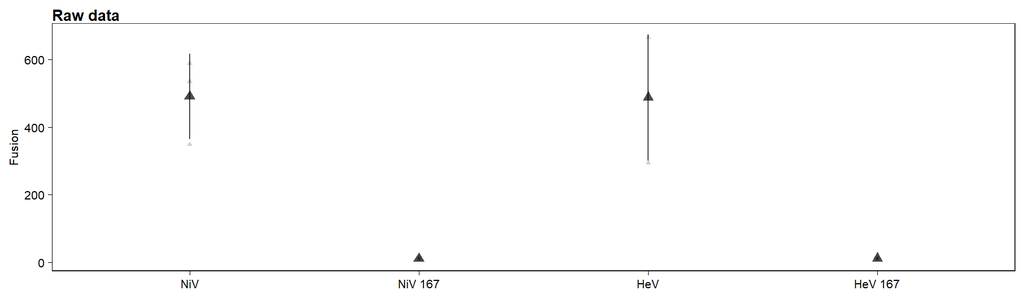

```r
# subset data of interest
NnH = subset(data, experiment == "fusion tagged NiV and HeV mutants",
             select = -c(experiment))

# calculate mean across technical replicates for figures
NnH_CSE_fusion_aggr = aggregate(value ~ variable + conditions + virus + replicate_bio + tag, data = NnH, mean)


NnH_fusion_aggr = subset(NnH_CSE_fusion_aggr, variable == "fusion_mean")

# plot raw data
ggplot(NnH_fusion_aggr, aes(x = virus, y = value)) +
  geom_point(size = 1, alpha = 0.7, position=position_dodge(width = 0.25), color = "grey", fill = "grey", shape = 17) +
  stat_summary(fun.data = mean_sdl, fun.args = list(mult = 1), position=position_dodge(width = 0.25), alpha = 0.7, shape = 17) +
  scale_x_discrete(labels = c("NiV", "NiV 167", "HeV", "HeV 167")) +
  scale_y_continuous(name = "Fusion") +
  ggtheme + theme(axis.title.x = element_blank(), legend.title = element_blank()) +
  ggtitle("Raw data")
```

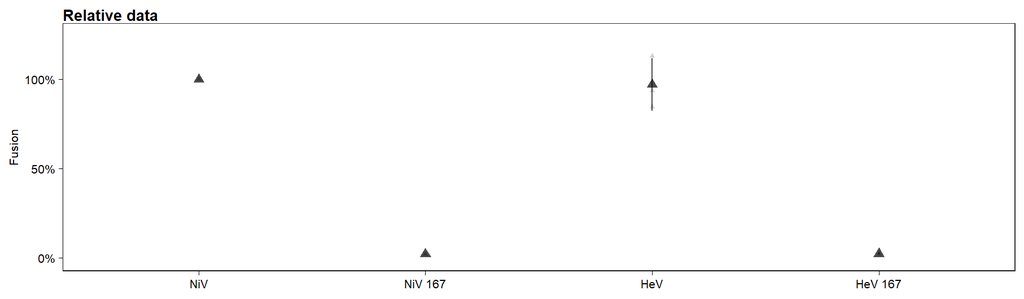

```r
# transform into relative data
NnH_fusion_aggr$value_relative = NA
for (i in 1:nrow(NnH_fusion_aggr)){
  NnH_fusion_aggr$value_relative[i] = NnH_fusion_aggr$value[i] /
    NnH_fusion_aggr[NnH_fusion_aggr$replicate_bio == NnH_fusion_aggr$replicate_bio[i] &
              NnH_fusion_aggr$variable == NnH_fusion_aggr$variable[i] &
              NnH_fusion_aggr$virus == "NiV", "value"]
}
remove(i)

# plot relative data
ggplot(NnH_fusion_aggr, aes(x = virus, y = value_relative)) +
  geom_point(size = 1, alpha = 0.7, position=position_dodge(width = 0.25), color = "grey", fill = "grey", shape = 17) +
  stat_summary(fun.data = mean_sdl, fun.args = list(mult = 1), position=position_dodge(width = 0.25), alpha = 0.7, shape = 17) +
  scale_x_discrete(labels = c("NiV", "NiV 167", "HeV", "HeV 167")) +
  scale_y_continuous(name = "Fusion", limits = c(-0.01, 1.25), breaks = seq(0, 1.25, 0.5), labels = scales::percent) +
  ggtheme + theme(axis.title.x = element_blank(), legend.title = element_blank()) +
  ggtitle("Relative data")
```

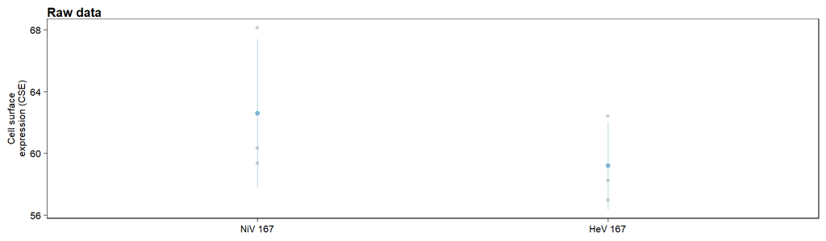

```r
NnH_CSE_aggr = subset(NnH_CSE_fusion_aggr, variable == "CSE_F")

# plot raw data
ggplot(NnH_CSE_aggr, aes(x = virus, y = value)) +
  geom_point(size = 1, alpha = 0.7, position=position_dodge(width = 0.25), color = "grey", fill = "grey") +
  stat_summary(fun.data = mean_sdl, fun.args = list(mult = 1), position=position_dodge(width = 0.25), alpha = 0.7, color = "#67a9cf", size = 0.25) +
  scale_x_discrete(labels = c("NiV 167", "HeV 167")) +
  scale_y_continuous(name = "Cell surface\nexpression (CSE)") +
  ggtheme + theme(axis.title.x = element_blank(), legend.title = element_blank()) +
  ggtitle("Raw data")
```

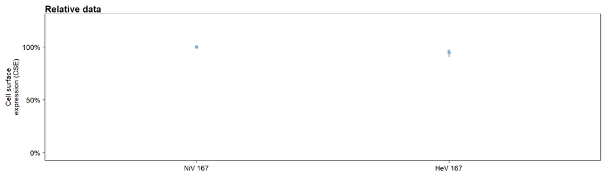

```r
# transform into relative data
NnH_CSE_aggr$value_relative = NA
for (i in 1:nrow(NnH_CSE_aggr)){
  NnH_CSE_aggr$value_relative[i] = NnH_CSE_aggr$value[i] /
    NnH_CSE_aggr[NnH_CSE_aggr$replicate_bio == NnH_CSE_aggr$replicate_bio[i] &
              NnH_CSE_aggr$variable == NnH_CSE_aggr$variable[i] &
              NnH_CSE_aggr$virus == "NiV_167", "value"]
}
remove(i)

# plot relative data
ggplot(NnH_CSE_aggr, aes(x = virus, y = value_relative)) +
  geom_point(size = 1, alpha = 0.7, position=position_dodge(width = 0.25), color = "grey", fill = "grey") +
  stat_summary(fun.data = mean_sdl, fun.args = list(mult = 1), position=position_dodge(width = 0.25), alpha = 0.7, size = 0.25, color = "#67a9cf") +
  scale_x_discrete(labels = c("NiV 167", "HeV 167")) +
  scale_y_continuous(name = "Cell surface\nexpression (CSE)", limits = c(-0.01, 1.25), breaks = seq(0, 1.25, 0.5), labels = scales::percent) +
  ggtheme + theme(axis.title.x = element_blank(), legend.title = element_blank()) +
  ggtitle("Relative data")
```